# Graded Project 1 - Python for Data Science

## Problem Statement

### Analyse & formulate a report for the Football Team Selection.

A new football club named ‘GL United FC’ has just been inaugurated. This club does not have a team yet. The team is looking to hire players for their roster. Management wants to make such decisions using a data based approach. During a recent hiring drive, you were selected for the Data Science team as a data scientist. Your team has been tasked with creating a report which recommends players for the main team.

### Dataset Description:

The data contains details for over 18,000 players playing in various football clubs in Europe. It contains information on age, skill rating, wages and player value, etc. The files provided are as follows:

- fifa.csv – data file.
- fifa_ variable_information.csv - information on individual variables.

## Load and explore data

### 1. Import the required libraries and read the dataset.

```python
## importing libraries

import numpy as np
import pandas as pd
%matplotlib inline
import matplotlib.pyplot as plt
import seaborn as sns
sns.set(style = "ticks")
import warnings
warnings.filterwarnings('ignore')
```

```python
## reading dataset

fifa_df = pd.read_csv('fifa.csv')

## setting max columns to none
pd.set_option('display.max_columns', None)


fifa_df
```

|  | ID | Name | Age | Photo | Nationality | Flag | Overall | Potential | Club | Club Logo | Value | Wage | Preferred Foot | International Reputation | Weak Foot | Skill Moves | Work Rate | Body Type | Position | Jersey Number | Joined | Loaned From | Contract Valid Until | Height | Weight | Crossing | Finishing | HeadingAccuracy | ShortPassing | … |
| --- | --- | --- | --- | --- | --- | --- | --- | --- | --- | --- | --- | --- | --- | --- | --- | --- | --- | --- | --- | --- | --- | --- | --- | --- | --- | --- | --- | --- | --- | --- |
| 0 | 158023 | L. Messi | 31 | https://cdn.sofifa.org/players/4/19/158023.png | Argentina | https://cdn.sofifa.org/flags/52.png | 94 | 94 | FC Barcelona | https://cdn.sofifa.org/teams/2/light/241.png | €110.5M | €565K | Left | 5.0 | 4.0 | 4.0 | Medium/ Medium | Messi | RF | 10.0 | Jul 1, 2004 | NaN | 2021 | 5'7 | 159lbs | 84.0 | 95.0 | 70.0 | 90.0 | … |
| 1 | 20801 | Cristiano Ronaldo | 33 | https://cdn.sofifa.org/players/4/19/20801.png | Portugal | https://cdn.sofifa.org/flags/38.png | 94 | 94 | Juventus | https://cdn.sofifa.org/teams/2/light/45.png | €77M | €405K | Right | 5.0 | 4.0 | 5.0 | High/ Low | C. Ronaldo | ST | 7.0 | Jul 10, 2018 | NaN | 2022 | 6'2 | 183lbs | 84.0 | 94.0 | 89.0 | 81.0 | … |
| 2 | 190871 | Neymar Jr | 26 | https://cdn.sofifa.org/players/4/19/190871.png | Brazil | https://cdn.sofifa.org/flags/54.png | 92 | 93 | Paris Saint-Germain | https://cdn.sofifa.org/teams/2/light/73.png | €118.5M | €290K | Right | 5.0 | 5.0 | 5.0 | High/ Medium | Neymar | LW | 10.0 | Aug 3, 2017 | NaN | 2022 | 5'9 | 150lbs | 79.0 | 87.0 | 62.0 | 84.0 | … |
| 3 | 193080 | De Gea | 27 | https://cdn.sofifa.org/players/4/19/193080.png | Spain | https://cdn.sofifa.org/flags/45.png | 91 | 93 | Manchester United | https://cdn.sofifa.org/teams/2/light/11.png | €72M | €260K | Right | 4.0 | 3.0 | 1.0 | Medium/ Medium | Lean | GK | 1.0 | Jul 1, 2011 | NaN | 2020 | 6'4 | 168lbs | 17.0 | 13.0 | 21.0 | 50.0 | … |
| 4 | 192985 | K. De Bruyne | 27 | https://cdn.sofifa.org/players/4/19/192985.png | Belgium | https://cdn.sofifa.org/flags/7.png | 91 | 92 | Manchester City | https://cdn.sofifa.org/teams/2/light/10.png | €102M | €355K | Right | 4.0 | 5.0 | 4.0 | High/ High | Normal | RCM | 7.0 | Aug 30, 2015 | NaN | 2023 | 5'11 | 154lbs | 93.0 | 82.0 | 55.0 | 92.0 | … |
| ... | ... | ... | ... | ... | ... | ... | ... | ... | ... | ... | ... | ... | ... | ... | ... | ... | ... | ... | ... | ... | ... | ... | ... | ... | ... | ... | ... | ... | ... | … |
| 18202 | 238813 | J. Lundstram | 19 | https://cdn.sofifa.org/players/4/19/238813.png | England | https://cdn.sofifa.org/flags/14.png | 47 | 65 | Crewe Alexandra | https://cdn.sofifa.org/teams/2/light/121.png | €60K | €1K | Right | 1.0 | 2.0 | 2.0 | Medium/ Medium | Lean | CM | 22.0 | May 3, 2017 | NaN | 2019 | 5'9 | 134lbs | 34.0 | 38.0 | 40.0 | 49.0 | … |
| 18203 | 243165 | N. Christoffersson | 19 | https://cdn.sofifa.org/players/4/19/243165.png | Sweden | https://cdn.sofifa.org/flags/46.png | 47 | 63 | Trelleborgs FF | https://cdn.sofifa.org/teams/2/light/703.png | €60K | €1K | Right | 1.0 | 2.0 | 2.0 | Medium/ Medium | Normal | ST | 21.0 | Mar 19, 2018 | NaN | 2020 | 6'3 | 170lbs | 23.0 | 52.0 | 52.0 | 43.0 | … |
| 18204 | 241638 | B. Worman | 16 | https://cdn.sofifa.org/players/4/19/241638.png | England | https://cdn.sofifa.org/flags/14.png | 47 | 67 | Cambridge United | https://cdn.sofifa.org/teams/2/light/1944.png | €60K | €1K | Right | 1.0 | 3.0 | 2.0 | Medium/ Medium | Normal | ST | 33.0 | Jul 1, 2017 | NaN | 2021 | 5'8 | 148lbs | 25.0 | 40.0 | 46.0 | 38.0 | … |
| 18205 | 246268 | D. Walker-Rice | 17 | https://cdn.sofifa.org/players/4/19/246268.png | England | https://cdn.sofifa.org/flags/14.png | 47 | 66 | Tranmere Rovers | https://cdn.sofifa.org/teams/2/light/15048.png | €60K | €1K | Right | 1.0 | 3.0 | 2.0 | Medium/ Medium | Lean | RW | 34.0 | Apr 24, 2018 | NaN | 2019 | 5'10 | 154lbs | 44.0 | 50.0 | 39.0 | 42.0 | … |
| 18206 | 246269 | G. Nugent | 16 | https://cdn.sofifa.org/players/4/19/246269.png | England | https://cdn.sofifa.org/flags/14.png | 46 | 66 | Tranmere Rovers | https://cdn.sofifa.org/teams/2/light/15048.png | €60K | €1K | Right | 1.0 | 3.0 | 2.0 | Medium/ Medium | Lean | CM | 33.0 | Oct 30, 2018 | NaN | 2019 | 5'10 | 176lbs | 41.0 | 34.0 | 46.0 | 48.0 | … |

18207 rows × 60 columns

### 2. Check the first few samples, shape, info of the data and try to familiarize yourself with different features.

```python
## fetching first 5 records
fifa_df.head()
```

|  | ID | Name | Age | Photo | Nationality | Flag | Overall | Potential | Club | Club Logo | Value | Wage | Preferred Foot | International Reputation | Weak Foot | Skill Moves | Work Rate | Body Type | Position | Jersey Number | Joined | Loaned From | Contract Valid Until | Height | Weight | Crossing | Finishing | HeadingAccuracy | ShortPassing | … |
| --- | --- | --- | --- | --- | --- | --- | --- | --- | --- | --- | --- | --- | --- | --- | --- | --- | --- | --- | --- | --- | --- | --- | --- | --- | --- | --- | --- | --- | --- | --- |
| 0 | 158023 | L. Messi | 31 | https://cdn.sofifa.org/players/4/19/158023.png | Argentina | https://cdn.sofifa.org/flags/52.png | 94 | 94 | FC Barcelona | https://cdn.sofifa.org/teams/2/light/241.png | €110.5M | €565K | Left | 5.0 | 4.0 | 4.0 | Medium/ Medium | Messi | RF | 10.0 | Jul 1, 2004 | NaN | 2021 | 5'7 | 159lbs | 84.0 | 95.0 | 70.0 | 90.0 | … |
| 1 | 20801 | Cristiano Ronaldo | 33 | https://cdn.sofifa.org/players/4/19/20801.png | Portugal | https://cdn.sofifa.org/flags/38.png | 94 | 94 | Juventus | https://cdn.sofifa.org/teams/2/light/45.png | €77M | €405K | Right | 5.0 | 4.0 | 5.0 | High/ Low | C. Ronaldo | ST | 7.0 | Jul 10, 2018 | NaN | 2022 | 6'2 | 183lbs | 84.0 | 94.0 | 89.0 | 81.0 | … |
| 2 | 190871 | Neymar Jr | 26 | https://cdn.sofifa.org/players/4/19/190871.png | Brazil | https://cdn.sofifa.org/flags/54.png | 92 | 93 | Paris Saint-Germain | https://cdn.sofifa.org/teams/2/light/73.png | €118.5M | €290K | Right | 5.0 | 5.0 | 5.0 | High/ Medium | Neymar | LW | 10.0 | Aug 3, 2017 | NaN | 2022 | 5'9 | 150lbs | 79.0 | 87.0 | 62.0 | 84.0 | … |
| 3 | 193080 | De Gea | 27 | https://cdn.sofifa.org/players/4/19/193080.png | Spain | https://cdn.sofifa.org/flags/45.png | 91 | 93 | Manchester United | https://cdn.sofifa.org/teams/2/light/11.png | €72M | €260K | Right | 4.0 | 3.0 | 1.0 | Medium/ Medium | Lean | GK | 1.0 | Jul 1, 2011 | NaN | 2020 | 6'4 | 168lbs | 17.0 | 13.0 | 21.0 | 50.0 | … |
| 4 | 192985 | K. De Bruyne | 27 | https://cdn.sofifa.org/players/4/19/192985.png | Belgium | https://cdn.sofifa.org/flags/7.png | 91 | 92 | Manchester City | https://cdn.sofifa.org/teams/2/light/10.png | €102M | €355K | Right | 4.0 | 5.0 | 4.0 | High/ High | Normal | RCM | 7.0 | Aug 30, 2015 | NaN | 2023 | 5'11 | 154lbs | 93.0 | 82.0 | 55.0 | 92.0 | … |

```python
## fetching basic information about the dataset
fifa_df.info()
```

```
<class 'pandas.core.frame.DataFrame'>
RangeIndex: 18207 entries, 0 to 18206
Data columns (total 60 columns):
 #   Column                    Non-Null Count  Dtype
---  ------                    --------------  -----
 0   ID                        18207 non-null  int64
 1   Name                      18207 non-null  object
 2   Age                       18207 non-null  int64
 3   Photo                     18207 non-null  object
 4   Nationality               18207 non-null  object
 5   Flag                      18207 non-null  object
 6   Overall                   18207 non-null  int64
 7   Potential                 18207 non-null  int64
 8   Club                      17966 non-null  object
 9   Club Logo                 18207 non-null  object
```

[output cut: 52 more lines]

```python
## fetching shape of dataframe
fifa_df.shape
```

```
(18207, 60)
```

```python
## fetching size of data
fifa_df.size
```

```
1092420
```

```python
## fetching dimension of dataframe
fifa_df.ndim
```

```
2
```

```python
## fetching dimension of series in the dataframe
fifa_df["Name"].ndim
```

```
1
```

```python
## checking the statistical summary of data
fifa_df.describe()
```

|  | ID | Age | Overall | Potential | International Reputation | Weak Foot | Skill Moves | Jersey Number | Crossing | Finishing | HeadingAccuracy | ShortPassing | Volleys | Dribbling | Curve | FKAccuracy | LongPassing | BallControl | Acceleration | SprintSpeed | Agility | Reactions | Balance | ShotPower | Jumping | Stamina | Strength | LongShots | Aggression | … |
| --- | --- | --- | --- | --- | --- | --- | --- | --- | --- | --- | --- | --- | --- | --- | --- | --- | --- | --- | --- | --- | --- | --- | --- | --- | --- | --- | --- | --- | --- | --- |
| count | 18207.000000 | 18207.000000 | 18207.000000 | 18207.000000 | 18159.000000 | 18159.000000 | 18159.000000 | 18147.000000 | 18159.000000 | 18159.000000 | 18159.000000 | 18159.000000 | 18159.000000 | 18159.000000 | 18159.000000 | 18159.000000 | 18159.000000 | 18159.000000 | 18159.000000 | 18159.000000 | 18159.000000 | 18159.000000 | 18159.000000 | 18159.000000 | 18159.000000 | 18159.000000 | 18159.000000 | 18159.000000 | 18159.000000 | … |
| mean | 214298.338606 | 25.122206 | 66.238699 | 71.307299 | 1.113222 | 2.947299 | 2.361308 | 19.546096 | 49.734181 | 45.550911 | 52.298144 | 58.686712 | 42.909026 | 55.371001 | 47.170824 | 42.863153 | 52.711933 | 58.369459 | 64.614076 | 64.726967 | 63.503607 | 61.836610 | 63.966573 | 55.460047 | 65.089432 | 63.219946 | 65.311967 | 47.109973 | 55.868991 | … |
| std | 29965.244204 | 4.669943 | 6.908930 | 6.136496 | 0.394031 | 0.660456 | 0.756164 | 15.947765 | 18.364524 | 19.525820 | 17.379909 | 14.699495 | 17.694408 | 18.910371 | 18.395264 | 17.478763 | 15.327870 | 16.686595 | 14.927780 | 14.649953 | 14.766049 | 9.010464 | 14.136166 | 17.237958 | 11.820044 | 15.894741 | 12.557000 | 19.260524 | 17.367967 | … |
| min | 16.000000 | 16.000000 | 46.000000 | 48.000000 | 1.000000 | 1.000000 | 1.000000 | 1.000000 | 5.000000 | 2.000000 | 4.000000 | 7.000000 | 4.000000 | 4.000000 | 6.000000 | 3.000000 | 9.000000 | 5.000000 | 12.000000 | 12.000000 | 14.000000 | 21.000000 | 16.000000 | 2.000000 | 15.000000 | 12.000000 | 17.000000 | 3.000000 | 11.000000 | … |
| 25% | 200315.500000 | 21.000000 | 62.000000 | 67.000000 | 1.000000 | 3.000000 | 2.000000 | 8.000000 | 38.000000 | 30.000000 | 44.000000 | 54.000000 | 30.000000 | 49.000000 | 34.000000 | 31.000000 | 43.000000 | 54.000000 | 57.000000 | 57.000000 | 55.000000 | 56.000000 | 56.000000 | 45.000000 | 58.000000 | 56.000000 | 58.000000 | 33.000000 | 44.000000 | … |
| 50% | 221759.000000 | 25.000000 | 66.000000 | 71.000000 | 1.000000 | 3.000000 | 2.000000 | 17.000000 | 54.000000 | 49.000000 | 56.000000 | 62.000000 | 44.000000 | 61.000000 | 48.000000 | 41.000000 | 56.000000 | 63.000000 | 67.000000 | 67.000000 | 66.000000 | 62.000000 | 66.000000 | 59.000000 | 66.000000 | 66.000000 | 67.000000 | 51.000000 | 59.000000 | … |
| 75% | 236529.500000 | 28.000000 | 71.000000 | 75.000000 | 1.000000 | 3.000000 | 3.000000 | 26.000000 | 64.000000 | 62.000000 | 64.000000 | 68.000000 | 57.000000 | 68.000000 | 62.000000 | 57.000000 | 64.000000 | 69.000000 | 75.000000 | 75.000000 | 74.000000 | 68.000000 | 74.000000 | 68.000000 | 73.000000 | 74.000000 | 74.000000 | 62.000000 | 69.000000 | … |
| max | 246620.000000 | 45.000000 | 94.000000 | 95.000000 | 5.000000 | 5.000000 | 5.000000 | 99.000000 | 93.000000 | 95.000000 | 94.000000 | 93.000000 | 90.000000 | 97.000000 | 94.000000 | 94.000000 | 93.000000 | 96.000000 | 97.000000 | 96.000000 | 96.000000 | 96.000000 | 96.000000 | 95.000000 | 95.000000 | 96.000000 | 97.000000 | 94.000000 | 95.000000 | … |

```python
## checking the statistical summary of data -- for object type
fifa_df.describe(include = 'O')
```

|  | Name | Photo | Nationality | Flag | Club | Club Logo | Value | Wage | Preferred Foot | Work Rate | Body Type | Position | Joined | Loaned From | Contract Valid Until | Height | Weight | Release Clause |
| --- | --- | --- | --- | --- | --- | --- | --- | --- | --- | --- | --- | --- | --- | --- | --- | --- | --- | --- |
| count | 18207 | 18207 | 18207 | 18207 | 17966 | 18207 | 18207 | 18207 | 18159 | 18159 | 18159 | 18147 | 16654 | 1264 | 17918 | 18159 | 18159 | 16643 |
| unique | 17194 | 18207 | 164 | 164 | 651 | 679 | 217 | 144 | 2 | 9 | 10 | 27 | 1736 | 341 | 36 | 21 | 57 | 1244 |
| top | J. Rodríguez | https://cdn.sofifa.org/players/4/19/158023.png | England | https://cdn.sofifa.org/flags/14.png | FC Barcelona | https://cdn.sofifa.org/teams/2/light/241.png | €1.1M | €1K | Right | Medium/ Medium | Normal | ST | Jul 1, 2018 | Atalanta | 2019 | 6'0 | 165lbs | €1.1M |
| freq | 11 | 1 | 1662 | 1662 | 33 | 33 | 431 | 4900 | 13948 | 9810 | 10595 | 2152 | 1538 | 20 | 4819 | 2881 | 1483 | 557 |

#### Inferences:

- There are 18207 entries and 60 columns in the dataset
- It consists of integer, float and object type of data
- Entire size of data is: (18207 x 60) = 1092420
- The dataframe is 2 dimentional (columns and rows); The entries of the column are 1 dimentional data
- It is evident that there are some null entries also in some columns

### 3. Drop the columns which you think redundant for the analysis

```python
## dropping columns - Photo, Flag, Club Logo
fifa_df.drop(['Photo','Flag','Club Logo'], axis = 1, inplace = True)
```

```python
## checking the dataset content after column drop
fifa_df
```

|  | ID | Name | Age | Nationality | Overall | Potential | Club | Value | Wage | Preferred Foot | International Reputation | Weak Foot | Skill Moves | Work Rate | Body Type | Position | Jersey Number | Joined | Loaned From | Contract Valid Until | Height | Weight | Crossing | Finishing | HeadingAccuracy | ShortPassing | Volleys | Dribbling | Curve | … |
| --- | --- | --- | --- | --- | --- | --- | --- | --- | --- | --- | --- | --- | --- | --- | --- | --- | --- | --- | --- | --- | --- | --- | --- | --- | --- | --- | --- | --- | --- | --- |
| 0 | 158023 | L. Messi | 31 | Argentina | 94 | 94 | FC Barcelona | €110.5M | €565K | Left | 5.0 | 4.0 | 4.0 | Medium/ Medium | Messi | RF | 10.0 | Jul 1, 2004 | NaN | 2021 | 5'7 | 159lbs | 84.0 | 95.0 | 70.0 | 90.0 | 86.0 | 97.0 | 93.0 | … |
| 1 | 20801 | Cristiano Ronaldo | 33 | Portugal | 94 | 94 | Juventus | €77M | €405K | Right | 5.0 | 4.0 | 5.0 | High/ Low | C. Ronaldo | ST | 7.0 | Jul 10, 2018 | NaN | 2022 | 6'2 | 183lbs | 84.0 | 94.0 | 89.0 | 81.0 | 87.0 | 88.0 | 81.0 | … |
| 2 | 190871 | Neymar Jr | 26 | Brazil | 92 | 93 | Paris Saint-Germain | €118.5M | €290K | Right | 5.0 | 5.0 | 5.0 | High/ Medium | Neymar | LW | 10.0 | Aug 3, 2017 | NaN | 2022 | 5'9 | 150lbs | 79.0 | 87.0 | 62.0 | 84.0 | 84.0 | 96.0 | 88.0 | … |
| 3 | 193080 | De Gea | 27 | Spain | 91 | 93 | Manchester United | €72M | €260K | Right | 4.0 | 3.0 | 1.0 | Medium/ Medium | Lean | GK | 1.0 | Jul 1, 2011 | NaN | 2020 | 6'4 | 168lbs | 17.0 | 13.0 | 21.0 | 50.0 | 13.0 | 18.0 | 21.0 | … |
| 4 | 192985 | K. De Bruyne | 27 | Belgium | 91 | 92 | Manchester City | €102M | €355K | Right | 4.0 | 5.0 | 4.0 | High/ High | Normal | RCM | 7.0 | Aug 30, 2015 | NaN | 2023 | 5'11 | 154lbs | 93.0 | 82.0 | 55.0 | 92.0 | 82.0 | 86.0 | 85.0 | … |
| ... | ... | ... | ... | ... | ... | ... | ... | ... | ... | ... | ... | ... | ... | ... | ... | ... | ... | ... | ... | ... | ... | ... | ... | ... | ... | ... | ... | ... | ... | … |
| 18202 | 238813 | J. Lundstram | 19 | England | 47 | 65 | Crewe Alexandra | €60K | €1K | Right | 1.0 | 2.0 | 2.0 | Medium/ Medium | Lean | CM | 22.0 | May 3, 2017 | NaN | 2019 | 5'9 | 134lbs | 34.0 | 38.0 | 40.0 | 49.0 | 25.0 | 42.0 | 30.0 | … |
| 18203 | 243165 | N. Christoffersson | 19 | Sweden | 47 | 63 | Trelleborgs FF | €60K | €1K | Right | 1.0 | 2.0 | 2.0 | Medium/ Medium | Normal | ST | 21.0 | Mar 19, 2018 | NaN | 2020 | 6'3 | 170lbs | 23.0 | 52.0 | 52.0 | 43.0 | 36.0 | 39.0 | 32.0 | … |
| 18204 | 241638 | B. Worman | 16 | England | 47 | 67 | Cambridge United | €60K | €1K | Right | 1.0 | 3.0 | 2.0 | Medium/ Medium | Normal | ST | 33.0 | Jul 1, 2017 | NaN | 2021 | 5'8 | 148lbs | 25.0 | 40.0 | 46.0 | 38.0 | 38.0 | 45.0 | 38.0 | … |
| 18205 | 246268 | D. Walker-Rice | 17 | England | 47 | 66 | Tranmere Rovers | €60K | €1K | Right | 1.0 | 3.0 | 2.0 | Medium/ Medium | Lean | RW | 34.0 | Apr 24, 2018 | NaN | 2019 | 5'10 | 154lbs | 44.0 | 50.0 | 39.0 | 42.0 | 40.0 | 51.0 | 34.0 | … |
| 18206 | 246269 | G. Nugent | 16 | England | 46 | 66 | Tranmere Rovers | €60K | €1K | Right | 1.0 | 3.0 | 2.0 | Medium/ Medium | Lean | CM | 33.0 | Oct 30, 2018 | NaN | 2019 | 5'10 | 176lbs | 41.0 | 34.0 | 46.0 | 48.0 | 30.0 | 43.0 | 40.0 | … |

18207 rows × 57 columns

#### Inferences:

- We dropped 3 unnecessary columns namely: Photo, Flag, Club Logo
- Currently we have only 57 columns with 3 columns removed (60 - 3 = 57)

## Data Cleaning and Preprocessing

### 4. Convert the columns "Value", "Wage", "Release Clause" to float datatype after getting rid of currency symbol and suffix.

```
- Note: When the record/entry has "M"(indicates millions) as suffix you need to multiply that value with 1000000
- When the record/entry has "K"(indicates thousands) as suffix you need to multiply that value with 1000
```

```python
## removing '€' symbol from column "Value"
fifa_df.Value = [x.strip('€') for x in fifa_df.Value]

## removing '€' symbol from column "Wage"
fifa_df.Wage = [x.strip('€') for x in fifa_df.Wage]

## removing '€' symbol from column "Release Clause"
fifa_df['Release Clause'] = [x.strip('€') for x in (fifa_df['Release Clause'].astype(str))]


fifa_df
```

|  | ID | Name | Age | Nationality | Overall | Potential | Club | Value | Wage | Preferred Foot | International Reputation | Weak Foot | Skill Moves | Work Rate | Body Type | Position | Jersey Number | Joined | Loaned From | Contract Valid Until | Height | Weight | Crossing | Finishing | HeadingAccuracy | ShortPassing | Volleys | Dribbling | Curve | … |
| --- | --- | --- | --- | --- | --- | --- | --- | --- | --- | --- | --- | --- | --- | --- | --- | --- | --- | --- | --- | --- | --- | --- | --- | --- | --- | --- | --- | --- | --- | --- |
| 0 | 158023 | L. Messi | 31 | Argentina | 94 | 94 | FC Barcelona | 110.5M | 565K | Left | 5.0 | 4.0 | 4.0 | Medium/ Medium | Messi | RF | 10.0 | Jul 1, 2004 | NaN | 2021 | 5'7 | 159lbs | 84.0 | 95.0 | 70.0 | 90.0 | 86.0 | 97.0 | 93.0 | … |
| 1 | 20801 | Cristiano Ronaldo | 33 | Portugal | 94 | 94 | Juventus | 77M | 405K | Right | 5.0 | 4.0 | 5.0 | High/ Low | C. Ronaldo | ST | 7.0 | Jul 10, 2018 | NaN | 2022 | 6'2 | 183lbs | 84.0 | 94.0 | 89.0 | 81.0 | 87.0 | 88.0 | 81.0 | … |
| 2 | 190871 | Neymar Jr | 26 | Brazil | 92 | 93 | Paris Saint-Germain | 118.5M | 290K | Right | 5.0 | 5.0 | 5.0 | High/ Medium | Neymar | LW | 10.0 | Aug 3, 2017 | NaN | 2022 | 5'9 | 150lbs | 79.0 | 87.0 | 62.0 | 84.0 | 84.0 | 96.0 | 88.0 | … |
| 3 | 193080 | De Gea | 27 | Spain | 91 | 93 | Manchester United | 72M | 260K | Right | 4.0 | 3.0 | 1.0 | Medium/ Medium | Lean | GK | 1.0 | Jul 1, 2011 | NaN | 2020 | 6'4 | 168lbs | 17.0 | 13.0 | 21.0 | 50.0 | 13.0 | 18.0 | 21.0 | … |
| 4 | 192985 | K. De Bruyne | 27 | Belgium | 91 | 92 | Manchester City | 102M | 355K | Right | 4.0 | 5.0 | 4.0 | High/ High | Normal | RCM | 7.0 | Aug 30, 2015 | NaN | 2023 | 5'11 | 154lbs | 93.0 | 82.0 | 55.0 | 92.0 | 82.0 | 86.0 | 85.0 | … |
| ... | ... | ... | ... | ... | ... | ... | ... | ... | ... | ... | ... | ... | ... | ... | ... | ... | ... | ... | ... | ... | ... | ... | ... | ... | ... | ... | ... | ... | ... | … |
| 18202 | 238813 | J. Lundstram | 19 | England | 47 | 65 | Crewe Alexandra | 60K | 1K | Right | 1.0 | 2.0 | 2.0 | Medium/ Medium | Lean | CM | 22.0 | May 3, 2017 | NaN | 2019 | 5'9 | 134lbs | 34.0 | 38.0 | 40.0 | 49.0 | 25.0 | 42.0 | 30.0 | … |
| 18203 | 243165 | N. Christoffersson | 19 | Sweden | 47 | 63 | Trelleborgs FF | 60K | 1K | Right | 1.0 | 2.0 | 2.0 | Medium/ Medium | Normal | ST | 21.0 | Mar 19, 2018 | NaN | 2020 | 6'3 | 170lbs | 23.0 | 52.0 | 52.0 | 43.0 | 36.0 | 39.0 | 32.0 | … |
| 18204 | 241638 | B. Worman | 16 | England | 47 | 67 | Cambridge United | 60K | 1K | Right | 1.0 | 3.0 | 2.0 | Medium/ Medium | Normal | ST | 33.0 | Jul 1, 2017 | NaN | 2021 | 5'8 | 148lbs | 25.0 | 40.0 | 46.0 | 38.0 | 38.0 | 45.0 | 38.0 | … |
| 18205 | 246268 | D. Walker-Rice | 17 | England | 47 | 66 | Tranmere Rovers | 60K | 1K | Right | 1.0 | 3.0 | 2.0 | Medium/ Medium | Lean | RW | 34.0 | Apr 24, 2018 | NaN | 2019 | 5'10 | 154lbs | 44.0 | 50.0 | 39.0 | 42.0 | 40.0 | 51.0 | 34.0 | … |
| 18206 | 246269 | G. Nugent | 16 | England | 46 | 66 | Tranmere Rovers | 60K | 1K | Right | 1.0 | 3.0 | 2.0 | Medium/ Medium | Lean | CM | 33.0 | Oct 30, 2018 | NaN | 2019 | 5'10 | 176lbs | 41.0 | 34.0 | 46.0 | 48.0 | 30.0 | 43.0 | 40.0 | … |

18207 rows × 57 columns

```python
## converting column "Value" to Float
## - multiply 1000000 for 'M' and 1000 for 'K'
fifa_df.Value = [float(x.strip('K'))*1000 if 'K' in x else float(x.strip('M'))*1000000 for x in fifa_df.Value]


fifa_df.Value
```

```
0        110500000.0
1         77000000.0
2        118500000.0
3         72000000.0
4        102000000.0
            ...
18202        60000.0
18203        60000.0
18204        60000.0
18205        60000.0
18206        60000.0
Name: Value, Length: 18207, dtype: float64
```

```python
## converting column "Wage" to Float
## - multiply 1000000 for 'M' and 1000 for 'K'
fifa_df.Wage = [float(x.strip('K'))*1000 if 'K' in x else float(x.strip('M'))*1000000 for x in fifa_df.Wage]


fifa_df.Wage
```

```
0        565000.0
1        405000.0
2        290000.0
3        260000.0
4        355000.0
           ...
18202      1000.0
18203      1000.0
18204      1000.0
18205      1000.0
18206      1000.0
Name: Wage, Length: 18207, dtype: float64
```

```python
## converting column "Release Clause" to Float
## - multiply 1000000 for 'M' and 1000 for 'K'
fifa_df['Release Clause'] = [float(x.strip('K'))*1000 if 'K' in x else float(x.strip('M'))*1000000
                                for x in (fifa_df['Release Clause'].astype(str))
                               ]


fifa_df['Release Clause']
```

```
0        226500000.0
1        127100000.0
2        228100000.0
3        138600000.0
4        196400000.0
            ...
18202       143000.0
18203       113000.0
18204       165000.0
18205       143000.0
18206       165000.0
Name: Release Clause, Length: 18207, dtype: float64
```

```python
## display entire dataset
fifa_df
```

|  | ID | Name | Age | Nationality | Overall | Potential | Club | Value | Wage | Preferred Foot | International Reputation | Weak Foot | Skill Moves | Work Rate | Body Type | Position | Jersey Number | Joined | Loaned From | Contract Valid Until | Height | Weight | Crossing | Finishing | HeadingAccuracy | ShortPassing | Volleys | Dribbling | Curve | … |
| --- | --- | --- | --- | --- | --- | --- | --- | --- | --- | --- | --- | --- | --- | --- | --- | --- | --- | --- | --- | --- | --- | --- | --- | --- | --- | --- | --- | --- | --- | --- |
| 0 | 158023 | L. Messi | 31 | Argentina | 94 | 94 | FC Barcelona | 110500000.0 | 565000.0 | Left | 5.0 | 4.0 | 4.0 | Medium/ Medium | Messi | RF | 10.0 | Jul 1, 2004 | NaN | 2021 | 5'7 | 159lbs | 84.0 | 95.0 | 70.0 | 90.0 | 86.0 | 97.0 | 93.0 | … |
| 1 | 20801 | Cristiano Ronaldo | 33 | Portugal | 94 | 94 | Juventus | 77000000.0 | 405000.0 | Right | 5.0 | 4.0 | 5.0 | High/ Low | C. Ronaldo | ST | 7.0 | Jul 10, 2018 | NaN | 2022 | 6'2 | 183lbs | 84.0 | 94.0 | 89.0 | 81.0 | 87.0 | 88.0 | 81.0 | … |
| 2 | 190871 | Neymar Jr | 26 | Brazil | 92 | 93 | Paris Saint-Germain | 118500000.0 | 290000.0 | Right | 5.0 | 5.0 | 5.0 | High/ Medium | Neymar | LW | 10.0 | Aug 3, 2017 | NaN | 2022 | 5'9 | 150lbs | 79.0 | 87.0 | 62.0 | 84.0 | 84.0 | 96.0 | 88.0 | … |
| 3 | 193080 | De Gea | 27 | Spain | 91 | 93 | Manchester United | 72000000.0 | 260000.0 | Right | 4.0 | 3.0 | 1.0 | Medium/ Medium | Lean | GK | 1.0 | Jul 1, 2011 | NaN | 2020 | 6'4 | 168lbs | 17.0 | 13.0 | 21.0 | 50.0 | 13.0 | 18.0 | 21.0 | … |
| 4 | 192985 | K. De Bruyne | 27 | Belgium | 91 | 92 | Manchester City | 102000000.0 | 355000.0 | Right | 4.0 | 5.0 | 4.0 | High/ High | Normal | RCM | 7.0 | Aug 30, 2015 | NaN | 2023 | 5'11 | 154lbs | 93.0 | 82.0 | 55.0 | 92.0 | 82.0 | 86.0 | 85.0 | … |
| ... | ... | ... | ... | ... | ... | ... | ... | ... | ... | ... | ... | ... | ... | ... | ... | ... | ... | ... | ... | ... | ... | ... | ... | ... | ... | ... | ... | ... | ... | … |
| 18202 | 238813 | J. Lundstram | 19 | England | 47 | 65 | Crewe Alexandra | 60000.0 | 1000.0 | Right | 1.0 | 2.0 | 2.0 | Medium/ Medium | Lean | CM | 22.0 | May 3, 2017 | NaN | 2019 | 5'9 | 134lbs | 34.0 | 38.0 | 40.0 | 49.0 | 25.0 | 42.0 | 30.0 | … |
| 18203 | 243165 | N. Christoffersson | 19 | Sweden | 47 | 63 | Trelleborgs FF | 60000.0 | 1000.0 | Right | 1.0 | 2.0 | 2.0 | Medium/ Medium | Normal | ST | 21.0 | Mar 19, 2018 | NaN | 2020 | 6'3 | 170lbs | 23.0 | 52.0 | 52.0 | 43.0 | 36.0 | 39.0 | 32.0 | … |
| 18204 | 241638 | B. Worman | 16 | England | 47 | 67 | Cambridge United | 60000.0 | 1000.0 | Right | 1.0 | 3.0 | 2.0 | Medium/ Medium | Normal | ST | 33.0 | Jul 1, 2017 | NaN | 2021 | 5'8 | 148lbs | 25.0 | 40.0 | 46.0 | 38.0 | 38.0 | 45.0 | 38.0 | … |
| 18205 | 246268 | D. Walker-Rice | 17 | England | 47 | 66 | Tranmere Rovers | 60000.0 | 1000.0 | Right | 1.0 | 3.0 | 2.0 | Medium/ Medium | Lean | RW | 34.0 | Apr 24, 2018 | NaN | 2019 | 5'10 | 154lbs | 44.0 | 50.0 | 39.0 | 42.0 | 40.0 | 51.0 | 34.0 | … |
| 18206 | 246269 | G. Nugent | 16 | England | 46 | 66 | Tranmere Rovers | 60000.0 | 1000.0 | Right | 1.0 | 3.0 | 2.0 | Medium/ Medium | Lean | CM | 33.0 | Oct 30, 2018 | NaN | 2019 | 5'10 | 176lbs | 41.0 | 34.0 | 46.0 | 48.0 | 30.0 | 43.0 | 40.0 | … |

18207 rows × 57 columns

#### Inferences:

- Currency symbol has been removed in columns namely: Value, Wage, Release Clause
- All 3 columns are converted to Float datatype (dtype: float64)
- 'K' has been replaced by multiplying 1000
- 'M' has been replaced by multiplying 1000000

### 5. Convert the column "Joined" into integer data type with keeping only the year

```python
## converting 'Joined' column data into date and getting year

from dateutil.parser import parse

fifa_df.Joined = ['0' if 'nan' in x else parse(x).year for x in fifa_df.Joined.astype(str)]
fifa_df.Joined = fifa_df.Joined.astype(int)

fifa_df.Joined
```

```
0        2004
1        2018
2        2017
3        2011
4        2015
         ...
18202    2017
18203    2018
18204    2017
18205    2018
18206    2018
Name: Joined, Length: 18207, dtype: int32
```

#### Inferences:

- Year has been extracted from the full date
- "Joined" column is converted to Integer datatype (dtype: int32)

### 6. Convert the column "Contract Valid Until" to pandas datetime type.

```python
## parsing column "Contract Valid Until" to pandas datetime type
fifa_df['Contract Valid Until'] = pd.to_datetime(fifa_df['Contract Valid Until'], errors='coerce', infer_datetime_format=True)

fifa_df['Contract Valid Until']
```

```
0       2021-01-01
1       2022-01-01
2       2022-01-01
3       2020-01-01
4       2023-01-01
           ...
18202   2019-01-01
18203   2020-01-01
18204   2021-01-01
18205   2019-01-01
18206   2019-01-01
Name: Contract Valid Until, Length: 18207, dtype: datetime64[ns]
```

#### Inferences:

- "Contract Valid Until" column is converted to pandas Datetime datatype (dtype: datetime64)

### 7. The column 'Height' is in inches with a quotation mark, Convert to float with decimal points.

```python
## converting "Height" column to inches by removing quotation mark
fifa_df.Height = ['0' if 'nan' in x else ((float(str(x).split("'")[0]) * 12) + (float(str(x).split("'")[1])))
                   for x in fifa_df.Height.astype(str)]
fifa_df.Height = fifa_df.Height.astype(float)

fifa_df.Height
```

```
0        67.0
1        74.0
2        69.0
3        76.0
4        71.0
         ...
18202    69.0
18203    75.0
18204    68.0
18205    70.0
18206    70.0
Name: Height, Length: 18207, dtype: float64
```

#### Inferences:

- "Height" column is converted to Float datatype (dtype: float64)
- Quotation mark has been removed and now height is in inches

### 8. The column "Weight" has the suffix as lbs, remove the suffix and convert to float.

```python
## converting "Weight" column to lbs by removing suffix
fifa_df.Weight = ['0' if 'nan' in x else float(x.strip("lbs")) for x in fifa_df.Weight.astype(str)]
fifa_df.Weight = fifa_df.Weight.astype(float)

fifa_df.Weight
```

```
0        159.0
1        183.0
2        150.0
3        168.0
4        154.0
         ...
18202    134.0
18203    170.0
18204    148.0
18205    154.0
18206    176.0
Name: Weight, Length: 18207, dtype: float64
```

#### Inferences:

- "Weight" column is converted to Float datatype (dtype: float64)
- 'lbs' suffix has been removed and now weight is in lbs

### 9. Check for the percentage of missing values and impute them with appropriate imputation techniques.

```python
## count total number of entries with missing values - column wise
fifa_df.isnull().sum()
```

```
ID                              0
Name                            0
Age                             0
Nationality                     0
Overall                         0
Potential                       0
Club                          241
Value                           0
Wage                            0
Preferred Foot                 48
International Reputation       48
Weak Foot                      48
Skill Moves                    48
Work Rate                      48
Body Type                      48
Position                       60
Jersey Number                  60
Joined                          0
Loaned From                 16943
Contract Valid Until          289
Height                          0
Weight                          0
Crossing                       48
Finishing                      48
HeadingAccuracy                48
ShortPassing                   48
Volleys                        48
Dribbling                      48
Curve                          48
FKAccuracy                     48
LongPassing                    48
BallControl                    48
Acceleration                   48
SprintSpeed                    48
Agility                        48
Reactions                      48
Balance                        48
ShotPower                      48
Jumping                        48
Stamina                        48
Strength                       48
LongShots                      48
Aggression                     48
Interceptions                  48
Positioning                    48
Vision                         48
Penalties                      48
Composure                      48
Marking                        48
StandingTackle                 48
SlidingTackle                  48
GKDiving                       48
GKHandling                     48
GKKicking                      48
GKPositioning                  48
GKReflexes                     48
Release Clause               1564
dtype: int64
```

```python
## percentage of missing entries - column wise
for i in range(fifa_df.shape[1]):
    col = fifa_df.columns.values.tolist()[i]
    n_miss = fifa_df[col].isna().sum()
    perc = n_miss / fifa_df.shape[0] * 100
    print(' %d  %s , Missing: %d    (%.1f%%)' % (i, col, n_miss, perc))
```

```
 0  ID , Missing: 0    (0.0%)
 1  Name , Missing: 0    (0.0%)
 2  Age , Missing: 0    (0.0%)
 3  Nationality , Missing: 0    (0.0%)
 4  Overall , Missing: 0    (0.0%)
 5  Potential , Missing: 0    (0.0%)
 6  Club , Missing: 241    (1.3%)
 7  Value , Missing: 0    (0.0%)
 8  Wage , Missing: 0    (0.0%)
 9  Preferred Foot , Missing: 48    (0.3%)
 10  International Reputation , Missing: 48    (0.3%)
 11  Weak Foot , Missing: 48    (0.3%)
 12  Skill Moves , Missing: 48    (0.3%)
 13  Work Rate , Missing: 48    (0.3%)
 14  Body Type , Missing: 48    (0.3%)
```

[output cut: 42 more lines]

```python
## including imputation for missing entries

## Imputation for column - float dataype
fifa_df[["International Reputation","Weak Foot","Skill Moves","Jersey Number","Crossing","Finishing"]] = fifa_df[["International Reputation","Weak Foot","Skill Moves","Jersey Number","Crossing","Finishing"]].fillna(0)
fifa_df[["HeadingAccuracy","ShortPassing","Volleys","Dribbling","Curve","FKAccuracy","LongPassing"]] = fifa_df[["HeadingAccuracy","ShortPassing","Volleys","Dribbling","Curve","FKAccuracy","LongPassing"]].fillna(0)
fifa_df[["BallControl","Acceleration","SprintSpeed","Agility","Reactions","Balance","ShotPower"]] = fifa_df[["BallControl","Acceleration","SprintSpeed","Agility","Reactions","Balance","ShotPower"]].fillna(0)
fifa_df[["Jumping","Stamina","Strength","LongShots","Aggression","Interceptions","Positioning"]] = fifa_df[["Jumping","Stamina","Strength","LongShots","Aggression","Interceptions","Positioning"]].fillna(0)
fifa_df[["Vision","Penalties","Composure","Marking","StandingTackle","SlidingTackle","GKDiving"]] = fifa_df[["Vision","Penalties","Composure","Marking","StandingTackle","SlidingTackle","GKDiving"]].fillna(0)
fifa_df[["GKHandling","GKKicking","GKPositioning","GKReflexes","Release Clause"]] = fifa_df[["GKHandling","GKKicking","GKPositioning","GKReflexes","Release Clause"]].fillna(0)

## Imputation for column - object datatype
fifa_df[["Club","Preferred Foot","Work Rate","Body Type","Position","Loaned From"]] = fifa_df[["Club","Preferred Foot","Work Rate","Body Type","Position","Loaned From"]].fillna('Missing')

## Imputation for column "Contract Valid Until" - datetime datatype
fifa_df['Contract Valid Until'] = pd.to_datetime(fifa_df['Contract Valid Until'], errors='coerce').ffill()


fifa_df.info()
```

```
<class 'pandas.core.frame.DataFrame'>
RangeIndex: 18207 entries, 0 to 18206
Data columns (total 57 columns):
 #   Column                    Non-Null Count  Dtype
---  ------                    --------------  -----
 0   ID                        18207 non-null  int64
 1   Name                      18207 non-null  object
 2   Age                       18207 non-null  int64
 3   Nationality               18207 non-null  object
 4   Overall                   18207 non-null  int64
 5   Potential                 18207 non-null  int64
 6   Club                      18207 non-null  object
 7   Value                     18207 non-null  float64
 8   Wage                      18207 non-null  float64
 9   Preferred Foot            18207 non-null  object
```

[output cut: 49 more lines]

```python
## checking null value count for each column
fifa_df.isnull().sum()
```

```
ID                          0
Name                        0
Age                         0
Nationality                 0
Overall                     0
Potential                   0
Club                        0
Value                       0
Wage                        0
Preferred Foot              0
International Reputation    0
Weak Foot                   0
Skill Moves                 0
Work Rate                   0
Body Type                   0
Position                    0
Jersey Number               0
Joined                      0
Loaned From                 0
Contract Valid Until        0
Height                      0
Weight                      0
Crossing                    0
Finishing                   0
HeadingAccuracy             0
ShortPassing                0
Volleys                     0
Dribbling                   0
Curve                       0
FKAccuracy                  0
LongPassing                 0
BallControl                 0
Acceleration                0
SprintSpeed                 0
Agility                     0
Reactions                   0
Balance                     0
ShotPower                   0
Jumping                     0
Stamina                     0
Strength                    0
LongShots                   0
Aggression                  0
Interceptions               0
Positioning                 0
Vision                      0
Penalties                   0
Composure                   0
Marking                     0
StandingTackle              0
SlidingTackle               0
GKDiving                    0
GKHandling                  0
GKKicking                   0
GKPositioning               0
GKReflexes                  0
Release Clause              0
dtype: int64
```

## Exploratory Data Analysis

### 10. Plot the distribution of Overall rating for all the players and write your findings

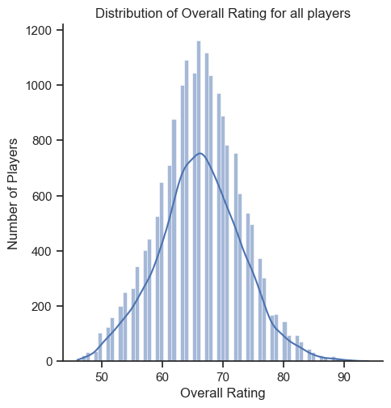

```python
## plotting the distribution of overall rating for players

rating_plot = sns.displot(fifa_df['Overall'], kde = True)
rating_plot.set(xlabel='Overall Rating',
                ylabel='Number of Players',
                title='Distribution of Overall Rating for all players')
plt.figure(1 , figsize = (15 , 6))
plt.show()
```

#### Inferences:

```python
## description of column 'Overall rating' of players
fifa_df.Overall.describe()
```

```
count    18207.000000
mean        66.238699
std          6.908930
min         46.000000
25%         62.000000
50%         66.000000
75%         71.000000
max         94.000000
Name: Overall, dtype: float64
```

### 11. Retrieve the names of top20 players based on the Overall rating.

```python
## getting names of top 20 players on rating

top_players = pd.DataFrame.copy(fifa_df.sort_values(by = 'Overall',ascending = False ).head(20))
top_players['Name']
```

```
0              L. Messi
1     Cristiano Ronaldo
2             Neymar Jr
3                De Gea
4          K. De Bruyne
5             E. Hazard
6             L. Modrić
7             L. Suárez
8          Sergio Ramos
12             D. Godín
13          David Silva
9              J. Oblak
11             T. Kroos
10       R. Lewandowski
20      Sergio Busquets
24         G. Chiellini
23            S. Agüero
22             M. Neuer
21            E. Cavani
16              H. Kane
Name: Name, dtype: object
```

#### Inferences:

- Names of top 20 players based on overall rating are displayed.
- Dataframe with Top 20 players is generated in the descending order of 'Overall rating' column and used here.

### 12. Generate a dataframe which should include all the information of the Top 20 players based on the Overall rating.

```python
## generating dataframe for top 20 players based on overall rating

top_players_data = pd.DataFrame.copy(fifa_df.sort_values(by = 'Overall',ascending = False ).head(20))
top_players_data
```

|  | ID | Name | Age | Nationality | Overall | Potential | Club | Value | Wage | Preferred Foot | International Reputation | Weak Foot | Skill Moves | Work Rate | Body Type | Position | Jersey Number | Joined | Loaned From | Contract Valid Until | Height | Weight | Crossing | Finishing | HeadingAccuracy | ShortPassing | Volleys | Dribbling | Curve | … |
| --- | --- | --- | --- | --- | --- | --- | --- | --- | --- | --- | --- | --- | --- | --- | --- | --- | --- | --- | --- | --- | --- | --- | --- | --- | --- | --- | --- | --- | --- | --- |
| 0 | 158023 | L. Messi | 31 | Argentina | 94 | 94 | FC Barcelona | 110500000.0 | 565000.0 | Left | 5.0 | 4.0 | 4.0 | Medium/ Medium | Messi | RF | 10.0 | 2004 | Missing | 2021-01-01 | 67.0 | 159.0 | 84.0 | 95.0 | 70.0 | 90.0 | 86.0 | 97.0 | 93.0 | … |
| 1 | 20801 | Cristiano Ronaldo | 33 | Portugal | 94 | 94 | Juventus | 77000000.0 | 405000.0 | Right | 5.0 | 4.0 | 5.0 | High/ Low | C. Ronaldo | ST | 7.0 | 2018 | Missing | 2022-01-01 | 74.0 | 183.0 | 84.0 | 94.0 | 89.0 | 81.0 | 87.0 | 88.0 | 81.0 | … |
| 2 | 190871 | Neymar Jr | 26 | Brazil | 92 | 93 | Paris Saint-Germain | 118500000.0 | 290000.0 | Right | 5.0 | 5.0 | 5.0 | High/ Medium | Neymar | LW | 10.0 | 2017 | Missing | 2022-01-01 | 69.0 | 150.0 | 79.0 | 87.0 | 62.0 | 84.0 | 84.0 | 96.0 | 88.0 | … |
| 3 | 193080 | De Gea | 27 | Spain | 91 | 93 | Manchester United | 72000000.0 | 260000.0 | Right | 4.0 | 3.0 | 1.0 | Medium/ Medium | Lean | GK | 1.0 | 2011 | Missing | 2020-01-01 | 76.0 | 168.0 | 17.0 | 13.0 | 21.0 | 50.0 | 13.0 | 18.0 | 21.0 | … |
| 4 | 192985 | K. De Bruyne | 27 | Belgium | 91 | 92 | Manchester City | 102000000.0 | 355000.0 | Right | 4.0 | 5.0 | 4.0 | High/ High | Normal | RCM | 7.0 | 2015 | Missing | 2023-01-01 | 71.0 | 154.0 | 93.0 | 82.0 | 55.0 | 92.0 | 82.0 | 86.0 | 85.0 | … |
| 5 | 183277 | E. Hazard | 27 | Belgium | 91 | 91 | Chelsea | 93000000.0 | 340000.0 | Right | 4.0 | 4.0 | 4.0 | High/ Medium | Normal | LF | 10.0 | 2012 | Missing | 2020-01-01 | 68.0 | 163.0 | 81.0 | 84.0 | 61.0 | 89.0 | 80.0 | 95.0 | 83.0 | … |
| 6 | 177003 | L. Modrić | 32 | Croatia | 91 | 91 | Real Madrid | 67000000.0 | 420000.0 | Right | 4.0 | 4.0 | 4.0 | High/ High | Lean | RCM | 10.0 | 2012 | Missing | 2020-01-01 | 68.0 | 146.0 | 86.0 | 72.0 | 55.0 | 93.0 | 76.0 | 90.0 | 85.0 | … |
| 7 | 176580 | L. Suárez | 31 | Uruguay | 91 | 91 | FC Barcelona | 80000000.0 | 455000.0 | Right | 5.0 | 4.0 | 3.0 | High/ Medium | Normal | RS | 9.0 | 2014 | Missing | 2021-01-01 | 72.0 | 190.0 | 77.0 | 93.0 | 77.0 | 82.0 | 88.0 | 87.0 | 86.0 | … |
| 8 | 155862 | Sergio Ramos | 32 | Spain | 91 | 91 | Real Madrid | 51000000.0 | 380000.0 | Right | 4.0 | 3.0 | 3.0 | High/ Medium | Normal | RCB | 15.0 | 2005 | Missing | 2020-01-01 | 72.0 | 181.0 | 66.0 | 60.0 | 91.0 | 78.0 | 66.0 | 63.0 | 74.0 | … |
| 12 | 182493 | D. Godín | 32 | Uruguay | 90 | 90 | Atlético Madrid | 44000000.0 | 125000.0 | Right | 3.0 | 3.0 | 2.0 | Medium/ High | Lean | CB | 10.0 | 2010 | Missing | 2019-01-01 | 74.0 | 172.0 | 55.0 | 42.0 | 92.0 | 79.0 | 47.0 | 53.0 | 49.0 | … |
| 13 | 168542 | David Silva | 32 | Spain | 90 | 90 | Manchester City | 60000000.0 | 285000.0 | Left | 4.0 | 2.0 | 4.0 | High/ Medium | Normal | LCM | 21.0 | 2010 | Missing | 2020-01-01 | 68.0 | 148.0 | 84.0 | 76.0 | 54.0 | 93.0 | 82.0 | 89.0 | 82.0 | … |
| 9 | 200389 | J. Oblak | 25 | Slovenia | 90 | 93 | Atlético Madrid | 68000000.0 | 94000.0 | Right | 3.0 | 3.0 | 1.0 | Medium/ Medium | Normal | GK | 1.0 | 2014 | Missing | 2021-01-01 | 74.0 | 192.0 | 13.0 | 11.0 | 15.0 | 29.0 | 13.0 | 12.0 | 13.0 | … |
| 11 | 182521 | T. Kroos | 28 | Germany | 90 | 90 | Real Madrid | 76500000.0 | 355000.0 | Right | 4.0 | 5.0 | 3.0 | Medium/ Medium | Normal | LCM | 8.0 | 2014 | Missing | 2022-01-01 | 72.0 | 168.0 | 88.0 | 76.0 | 54.0 | 92.0 | 82.0 | 81.0 | 86.0 | … |
| 10 | 188545 | R. Lewandowski | 29 | Poland | 90 | 90 | FC Bayern München | 77000000.0 | 205000.0 | Right | 4.0 | 4.0 | 4.0 | High/ Medium | Normal | ST | 9.0 | 2014 | Missing | 2021-01-01 | 72.0 | 176.0 | 62.0 | 91.0 | 85.0 | 83.0 | 89.0 | 85.0 | 77.0 | … |
| 20 | 189511 | Sergio Busquets | 29 | Spain | 89 | 89 | FC Barcelona | 51500000.0 | 315000.0 | Right | 4.0 | 3.0 | 3.0 | Medium/ Medium | Lean | CDM | 5.0 | 2008 | Missing | 2023-01-01 | 74.0 | 168.0 | 62.0 | 67.0 | 68.0 | 89.0 | 44.0 | 80.0 | 66.0 | … |
| 24 | 138956 | G. Chiellini | 33 | Italy | 89 | 89 | Juventus | 27000000.0 | 215000.0 | Left | 4.0 | 3.0 | 2.0 | Medium/ High | Normal | LCB | 3.0 | 2005 | Missing | 2020-01-01 | 74.0 | 187.0 | 58.0 | 33.0 | 83.0 | 59.0 | 45.0 | 58.0 | 60.0 | … |
| 23 | 153079 | S. Agüero | 30 | Argentina | 89 | 89 | Manchester City | 64500000.0 | 300000.0 | Right | 4.0 | 4.0 | 4.0 | High/ Medium | Stocky | ST | 10.0 | 2011 | Missing | 2021-01-01 | 68.0 | 154.0 | 70.0 | 93.0 | 77.0 | 81.0 | 85.0 | 89.0 | 82.0 | … |
| 22 | 167495 | M. Neuer | 32 | Germany | 89 | 89 | FC Bayern München | 38000000.0 | 130000.0 | Right | 5.0 | 4.0 | 1.0 | Medium/ Medium | Normal | GK | 1.0 | 2011 | Missing | 2021-01-01 | 76.0 | 203.0 | 15.0 | 13.0 | 25.0 | 55.0 | 11.0 | 30.0 | 14.0 | … |
| 21 | 179813 | E. Cavani | 31 | Uruguay | 89 | 89 | Paris Saint-Germain | 60000000.0 | 200000.0 | Right | 4.0 | 4.0 | 3.0 | High/ High | Lean | LS | 21.0 | 2013 | Missing | 2020-01-01 | 73.0 | 170.0 | 70.0 | 89.0 | 89.0 | 78.0 | 90.0 | 80.0 | 77.0 | … |
| 16 | 202126 | H. Kane | 24 | England | 89 | 91 | Tottenham Hotspur | 83500000.0 | 205000.0 | Right | 3.0 | 4.0 | 3.0 | High/ High | Normal | ST | 9.0 | 2010 | Missing | 2024-01-01 | 74.0 | 196.0 | 75.0 | 94.0 | 85.0 | 80.0 | 84.0 | 80.0 | 78.0 | … |

#### Inferences:

- Dataframe with Top 20 players is generated in the descending order of 'Overall rating' column.
- Entire data of the top 20 players based on overall rating are displayed.

### 13. What is the average "Age" and "Wage" of these top 20 players? (use the data frame created in the question 11)

```python
## Computing average value of 'age' and 'wage' of top 20 players

result = top_players[['Age','Wage']].mean()
result
```

```
Age         29.55
Wage    294950.00
dtype: float64
```

#### Inferences:

- Average of 'Age' and 'Wage' column are displayed for the Top 20 players based on Overall rating.
  - Average age of top 20 players is 29.55 years
  - Average Wage of top 20 players is €294.95K
- Dataframe from Q11 is used for the calculation of data.

### 14. Among the top 20 players based on the Overall rating, which player has the highest wage? Display the name of the player with his wage.

```python
## Fetching the player's name and wage, among the top 20 players, who has the highest wage

Max_wage_df = top_players.sort_values(by='Wage', ascending = False)[['Name','Wage']].head(1)
Max_wage_df
```

|  | Name | Wage |
| --- | --- | --- |
| 0 | L. Messi | 565000.0 |

#### Inferences:

- Dataframe is generated for top 20 players based on Overall Rating.
- L. Messi has the highest wage among the overall rating based top 20 players.
- He receives wage of €565K.

### 15. Generate a dataframe which should include the "Player name", "Club Name", "Wage", and 'Overall rating'.

```
- i) find the average Overall rating for each club.
- ii) Display the average overall rating of Top10 Clubs using a plot
```

```python
## generating dataframe
result_df = pd.DataFrame.copy(fifa_df[['Name','Club','Wage','Overall']])
result_df
```

|  | Name | Club | Wage | Overall |
| --- | --- | --- | --- | --- |
| 0 | L. Messi | FC Barcelona | 565000.0 | 94 |
| 1 | Cristiano Ronaldo | Juventus | 405000.0 | 94 |
| 2 | Neymar Jr | Paris Saint-Germain | 290000.0 | 92 |
| 3 | De Gea | Manchester United | 260000.0 | 91 |
| 4 | K. De Bruyne | Manchester City | 355000.0 | 91 |
| ... | ... | ... | ... | ... |
| 18202 | J. Lundstram | Crewe Alexandra | 1000.0 | 47 |
| 18203 | N. Christoffersson | Trelleborgs FF | 1000.0 | 47 |
| 18204 | B. Worman | Cambridge United | 1000.0 | 47 |
| 18205 | D. Walker-Rice | Tranmere Rovers | 1000.0 | 47 |
| 18206 | G. Nugent | Tranmere Rovers | 1000.0 | 46 |

18207 rows × 4 columns

```python
## i) average Overall rating for each club
avg_rating_club = result_df.groupby(['Club'])[['Overall']].mean()
avg_rating_club.T
```

| Club | SSV Jahn Regensburg | 1. FC Heidenheim 1846 | 1. FC Kaiserslautern | 1. FC Köln | 1. FC Magdeburg | 1. FC Nürnberg | 1. FC Union Berlin | 1. FSV Mainz 05 | AC Ajaccio | AC Horsens | AD Alcorcón | ADO Den Haag | AEK Athens | AFC Wimbledon | AIK | AJ Auxerre | AS Béziers | AS Monaco | AS Nancy Lorraine | AS Saint-Étienne | AZ Alkmaar | Aalborg BK | Aarhus GF | Aberdeen | Accrington Stanley | Adelaide United | Ajax | Akhisar Belediyespor | Al Ahli | … |
| --- | --- | --- | --- | --- | --- | --- | --- | --- | --- | --- | --- | --- | --- | --- | --- | --- | --- | --- | --- | --- | --- | --- | --- | --- | --- | --- | --- | --- | --- | --- |
| Overall | 65.586207 | 65.75 | 63.384615 | 70.785714 | 65.615385 | 68.827586 | 68.321429 | 70.84375 | 65.043478 | 60.64 | 67.413793 | 66.678571 | 70.214286 | 60.461538 | 65.074074 | 66.296296 | 62.038462 | 72.939394 | 64.666667 | 70.875 | 70.0 | 62.037037 | 61.407407 | 64.333333 | 61.178571 | 61.4 | 73.633333 | 69.115385 | 65.7 | … |

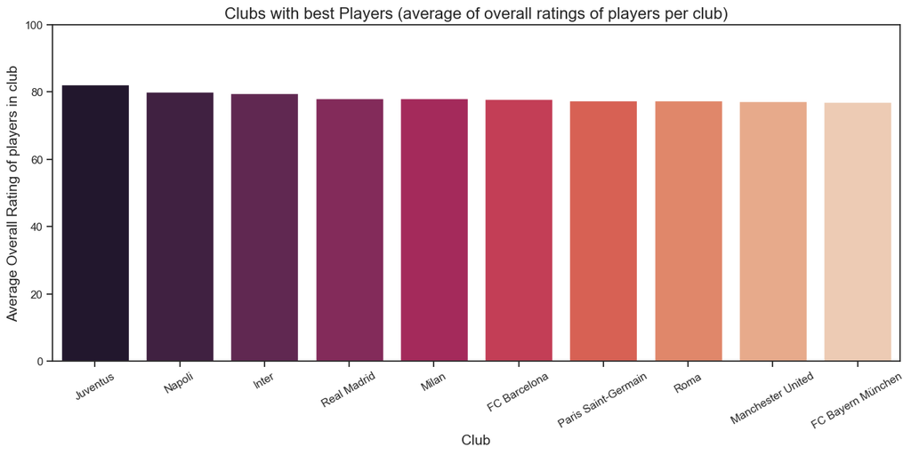

```python
## ii) average overall rating of Top10 Clubs using a plot

best_dict = {}
for club in result_df['Club'].unique():
    overall_rating = result_df['Overall'][result_df['Club'] == club].mean()
    best_dict[club] = overall_rating

best_club = pd.DataFrame.from_dict(best_dict, orient = 'index', columns = ['overall'])
best_club['club'] = best_club.index
best_club = best_club.sort_values(by = 'overall', ascending =  False)

plt.figure(1 , figsize = (15 , 6))
sns.barplot(x ='club', y ='overall', data = best_club.head(10), palette = 'rocket')
plt.xticks(rotation = 30)

plt.xlabel('Club', fontsize = 14)
plt.ylabel('Average Overall Rating of players in club', fontsize = 14)
plt.title('Clubs with best Players (average of overall ratings of players per club)', fontsize = 16)
plt.ylim(0 , 100)

plt.show()
```

#### Inferences:

- Dataframe is generated with data like "Player name", "Club Name", "Wage" and "Overall rating".
- Average of overall rating was calculated for each unique club.
  - Average value lies between 53.65 - 82.28
- Average overall rating of players from top 10 clubs is retrieved and plotted as bar chart.
- From the plot, it is observed that:
  - 'Juventus' club has the highest average rating of 82.28
  - 'FC Bayern Munchen' club ranks 10th with average rating of 77.0
  - Top 10 clubs are also visible and derived in plot

### 16. What is the relationship between age and individual potential of the player? Visualize the relationship with appropriate plot and Comment on the same.

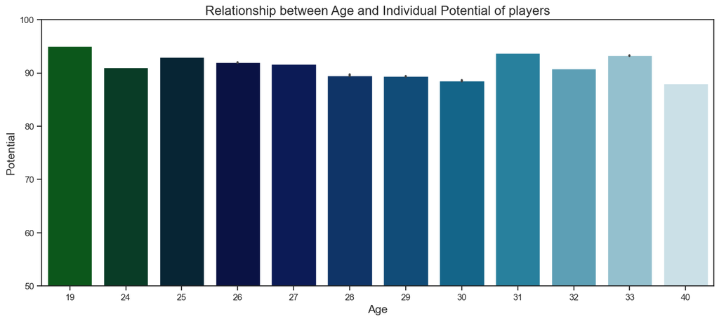

```python
## Plotting relationship between age and potential of players

age_potential_df = fifa_df.loc[fifa_df['Potential'] & fifa_df['Age']]
plt.figure(1 , figsize = (15,6))
sns.barplot(x = 'Age', y = 'Potential', data = age_potential_df, palette = 'ocean')

plt.xlabel('Age', fontsize = 14)
plt.ylabel('Potential', fontsize = 14)
plt.title('Relationship between Age and Individual Potential of players', fontsize = 16)
plt.ylim(50 , 100)

plt.show()
```

### 17. Which features directly contribute to the wages of the players? Support your answer with a plot and a metric.

```python
#  (hint: use potential, Overall, value, international reputation, and Release Clause)

## generating dataframe
relation_df = pd.DataFrame.copy(fifa_df[['Wage','Potential','Overall','Value','International Reputation','Release Clause']])
relation_df
```

|  | Wage | Potential | Overall | Value | International Reputation | Release Clause |
| --- | --- | --- | --- | --- | --- | --- |
| 0 | 565000.0 | 94 | 94 | 110500000.0 | 5.0 | 226500000.0 |
| 1 | 405000.0 | 94 | 94 | 77000000.0 | 5.0 | 127100000.0 |
| 2 | 290000.0 | 93 | 92 | 118500000.0 | 5.0 | 228100000.0 |
| 3 | 260000.0 | 93 | 91 | 72000000.0 | 4.0 | 138600000.0 |
| 4 | 355000.0 | 92 | 91 | 102000000.0 | 4.0 | 196400000.0 |
| ... | ... | ... | ... | ... | ... | ... |
| 18202 | 1000.0 | 65 | 47 | 60000.0 | 1.0 | 143000.0 |
| 18203 | 1000.0 | 63 | 47 | 60000.0 | 1.0 | 113000.0 |
| 18204 | 1000.0 | 67 | 47 | 60000.0 | 1.0 | 165000.0 |
| 18205 | 1000.0 | 66 | 47 | 60000.0 | 1.0 | 143000.0 |
| 18206 | 1000.0 | 66 | 46 | 60000.0 | 1.0 | 165000.0 |

18207 rows × 6 columns

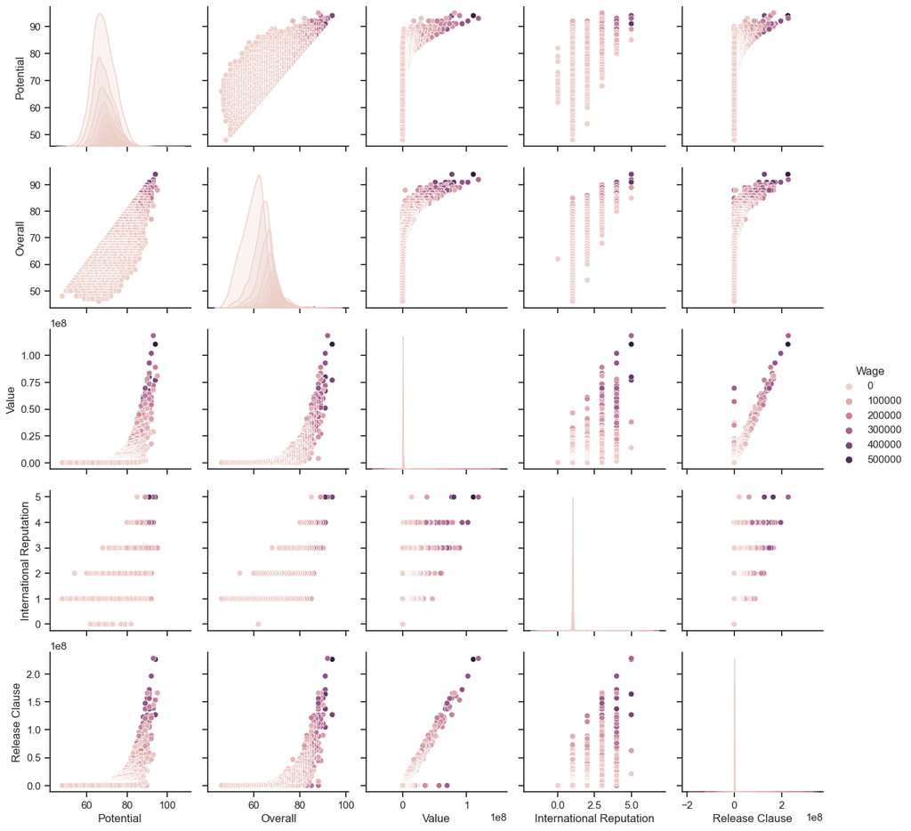

```python
## plot of relation with various features with column 'Wage'

plt.figure(1 , figsize = (12,8))
grid1 = sns.pairplot(relation_df, hue = 'Wage', diag_kind = 'kde')

plt.show()
```

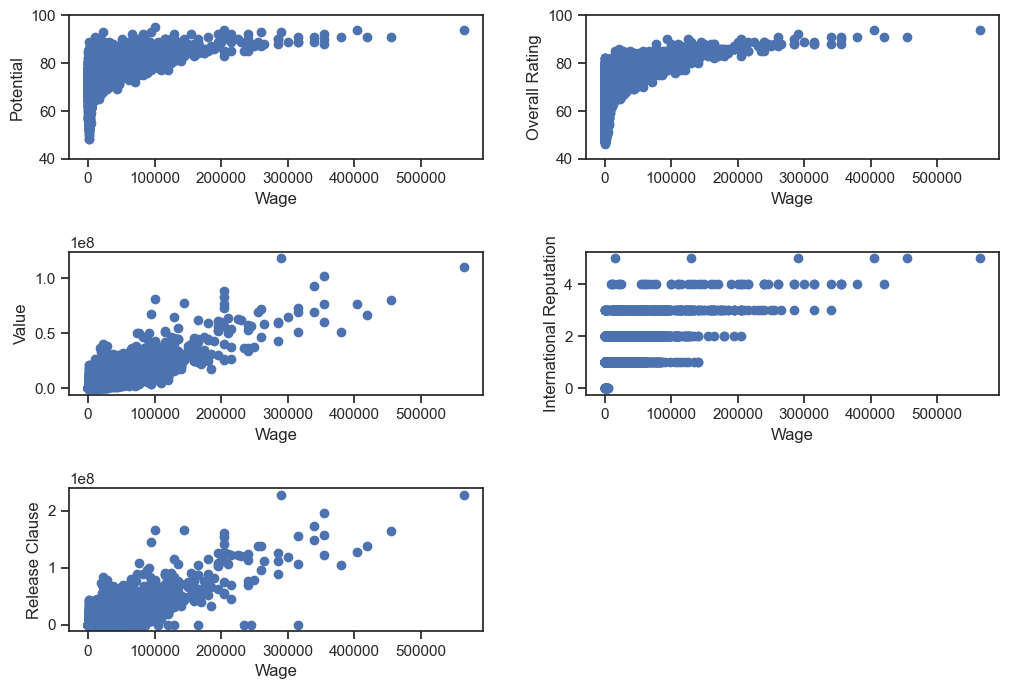

```python
## multiple sub-plots for relation with column 'Wage'
rows = 3
columns = 2
plt.figure(figsize = (12, 8))
grid = plt.GridSpec(rows, columns, wspace = .25, hspace = .65)

plt.subplot(grid[0])
plt.scatter(relation_df['Wage'], relation_df['Potential'])
plt.xlabel('Wage')
plt.ylabel('Potential')
plt.ylim(40, 100)

plt.subplot(grid[1])
plt.scatter(relation_df['Wage'], relation_df['Overall'])
plt.xlabel('Wage')
plt.ylabel('Overall Rating')
plt.ylim(40, 100)

plt.subplot(grid[2])
plt.scatter(relation_df['Wage'], relation_df['Value'])
plt.xlabel('Wage')
plt.ylabel('Value')

plt.subplot(grid[3])
plt.scatter(relation_df['Wage'], relation_df['International Reputation'])
plt.xlabel('Wage')
plt.ylabel('International Reputation')

plt.subplot(grid[4])
plt.scatter(relation_df['Wage'], relation_df['Release Clause'])
plt.xlabel('Wage')
plt.ylabel('Release Clause')
```

### 18. Find the position in the pitch where the maximum number of players play and the position where the minimum number of players play? Display it using a plot

```python
## fetching pitch position where maximum and minimum number of players are observed

position_df = fifa_df['Position'].value_counts()
list = position_df.index.tolist()

print('Pitch Position of Maximum number of players : ', list[0])
print('Pitch Position of Minimum number of players : ', list[-1])
```

```
Pitch Position of Maximum number of players :  ST
Pitch Position of Minimum number of players :  LF
```

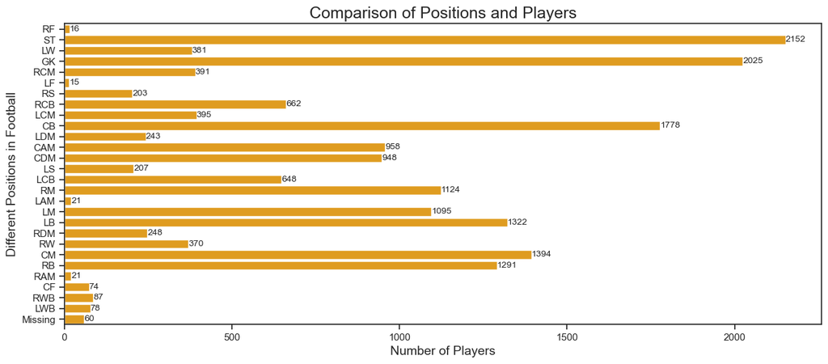

```python
## count plot for players based on position

plt.figure(figsize = (15, 6))
position_df = sns.countplot(y = fifa_df['Position'], color = 'orange')

position_df.set_xlabel(xlabel = 'Number of Players', fontsize = 14)
position_df.set_ylabel(ylabel = 'Different Positions in Football', fontsize = 14)
position_df.set_title(label = 'Comparison of Positions and Players', fontsize = 18)

position_df.bar_label(position_df.containers[0], fontsize = 10)

plt.show()
```

#### Inferences:

- Dataframe is generated for Pitch position of all players.
- The pitch position of maximum and mimimun number of players is computed and displayed.
  - Pitch position 'ST' is used by maximum players
  - Pitch position 'LF' is used by minimum players
- The relation is plotted using Count-plot with the count of players displayed alongside.
- 'ST' pitch position (maximum) is used by about 2152 players.
- 'LF' pitch position (minimum) is used by about 15 players.

### 19. How many players are from the club 'Juventus' and the wage is greater than 200K? Display all the information of such players.

```python
## dataframe of players from club "Juventus" whose wage is greater than 200K

Juventus_df = fifa_df[fifa_df['Club'] == 'Juventus']
high_df =  Juventus_df[Juventus_df['Wage'] > 200000]

high_df
```

|  | ID | Name | Age | Nationality | Overall | Potential | Club | Value | Wage | Preferred Foot | International Reputation | Weak Foot | Skill Moves | Work Rate | Body Type | Position | Jersey Number | Joined | Loaned From | Contract Valid Until | Height | Weight | Crossing | Finishing | HeadingAccuracy | ShortPassing | Volleys | Dribbling | Curve | … |
| --- | --- | --- | --- | --- | --- | --- | --- | --- | --- | --- | --- | --- | --- | --- | --- | --- | --- | --- | --- | --- | --- | --- | --- | --- | --- | --- | --- | --- | --- | --- |
| 1 | 20801 | Cristiano Ronaldo | 33 | Portugal | 94 | 94 | Juventus | 77000000.0 | 405000.0 | Right | 5.0 | 4.0 | 5.0 | High/ Low | C. Ronaldo | ST | 7.0 | 2018 | Missing | 2022-01-01 | 74.0 | 183.0 | 84.0 | 94.0 | 89.0 | 81.0 | 87.0 | 88.0 | 81.0 | … |
| 15 | 211110 | P. Dybala | 24 | Argentina | 89 | 94 | Juventus | 89000000.0 | 205000.0 | Left | 3.0 | 3.0 | 4.0 | High/ Medium | Normal | LF | 21.0 | 2015 | Missing | 2022-01-01 | 70.0 | 165.0 | 82.0 | 84.0 | 68.0 | 87.0 | 88.0 | 92.0 | 88.0 | … |
| 24 | 138956 | G. Chiellini | 33 | Italy | 89 | 89 | Juventus | 27000000.0 | 215000.0 | Left | 4.0 | 3.0 | 2.0 | Medium/ High | Normal | LCB | 3.0 | 2005 | Missing | 2020-01-01 | 74.0 | 187.0 | 58.0 | 33.0 | 83.0 | 59.0 | 45.0 | 58.0 | 60.0 | … |

```python
print('Number of players from club "Juventus" whose wage is greater than 200K :  ', len(high_df.index))
```

```
Number of players from club "Juventus" whose wage is greater than 200K :   3
```

#### Inferences:

- Dataframe is generated and displayed for players belonging to club 'Juventus' whose wage is greater than 200K.
- There are only 3 players who meet the required criteria from club 'Juventus'.
- Christiana Ronaldo receives the highest wage of 405K.

### 20. Generate a data frame containing top 5 players by Overall rating for each unique position.

```python
## dataframe of top 5 players by Overall rating for each unique Position


def top_position_uniq(val):
    for pos in fifa_df['Position'].unique():
        top_overall_rating = fifa_df['Overall'][fifa_df['Position'] == pos].head(5)
        i = 0
        res1_df = {}
        for i in range(5):
            res1_df[i] = top_overall_rating.index[i]
            i = i+1

        best_pos_df1 = pd.DataFrame.from_dict(res1_df, orient='index', columns = ['index'])

        if str(val) is 'df':
            print('---------------------------------------------------------------------------------------------------------------')
            print('Dataframe of top 5 players based on Overall rating with Position : ' + pos)
            display(fifa_df.loc[best_pos_df1['index']])
            print('---------------------------------------------------------------------------------------------------------------')
            print()
            print()
        else:
            sample_df = fifa_df.loc[best_pos_df1['index']]
            print(sample_df.groupby('Position')[['Wage']].mean().T)
            print('----------------------')
    return


top_position_uniq('df')
```

```
---------------------------------------------------------------------------------------------------------------
Dataframe of top 5 players based on Overall rating with Position : RF
```

|  | ID | Name | Age | Nationality | Overall | Potential | Club | Value | Wage | Preferred Foot | International Reputation | Weak Foot | Skill Moves | Work Rate | Body Type | Position | Jersey Number | Joined | Loaned From | Contract Valid Until | Height | Weight | Crossing | Finishing | HeadingAccuracy | ShortPassing | Volleys | Dribbling | Curve | … |
| --- | --- | --- | --- | --- | --- | --- | --- | --- | --- | --- | --- | --- | --- | --- | --- | --- | --- | --- | --- | --- | --- | --- | --- | --- | --- | --- | --- | --- | --- | --- |
| 0 | 158023 | L. Messi | 31 | Argentina | 94 | 94 | FC Barcelona | 110500000.0 | 565000.0 | Left | 5.0 | 4.0 | 4.0 | Medium/ Medium | Messi | RF | 10.0 | 2004 | Missing | 2021-01-01 | 67.0 | 159.0 | 84.0 | 95.0 | 70.0 | 90.0 | 86.0 | 97.0 | 93.0 | … |
| 50 | 175943 | D. Mertens | 31 | Belgium | 87 | 87 | Napoli | 45000000.0 | 135000.0 | Right | 3.0 | 4.0 | 4.0 | High/ Low | Normal | RF | 14.0 | 2013 | Missing | 2020-01-01 | 67.0 | 134.0 | 77.0 | 86.0 | 35.0 | 82.0 | 70.0 | 91.0 | 82.0 | … |
| 528 | 172114 | D. Valeri | 32 | Argentina | 80 | 80 | Portland Timbers | 11500000.0 | 12000.0 | Right | 2.0 | 3.0 | 3.0 | High/ Medium | Lean | RF | 8.0 | 2013 | Missing | 2018-01-01 | 70.0 | 165.0 | 78.0 | 80.0 | 70.0 | 79.0 | 75.0 | 78.0 | 80.0 | … |
| 890 | 150516 | L. Podolski | 33 | Germany | 78 | 78 | Vissel Kobe | 6500000.0 | 11000.0 | Left | 3.0 | 3.0 | 4.0 | Medium/ Low | Normal | RF | 10.0 | 2017 | Missing | 2019-01-01 | 72.0 | 183.0 | 75.0 | 77.0 | 66.0 | 76.0 | 88.0 | 78.0 | 80.0 | … |
| 1774 | 201313 | C. Ciano | 28 | Italy | 75 | 75 | Frosinone | 6500000.0 | 17000.0 | Left | 1.0 | 4.0 | 4.0 | High/ Medium | Normal | RF | 28.0 | 2017 | Missing | 2021-01-01 | 69.0 | 161.0 | 72.0 | 70.0 | 60.0 | 73.0 | 67.0 | 76.0 | 75.0 | … |

```
---------------------------------------------------------------------------------------------------------------


---------------------------------------------------------------------------------------------------------------
Dataframe of top 5 players based on Overall rating with Position : ST
```

|  | ID | Name | Age | Nationality | Overall | Potential | Club | Value | Wage | Preferred Foot | International Reputation | Weak Foot | Skill Moves | Work Rate | Body Type | Position | Jersey Number | Joined | Loaned From | Contract Valid Until | Height | Weight | Crossing | Finishing | HeadingAccuracy | ShortPassing | Volleys | Dribbling | Curve | … |
| --- | --- | --- | --- | --- | --- | --- | --- | --- | --- | --- | --- | --- | --- | --- | --- | --- | --- | --- | --- | --- | --- | --- | --- | --- | --- | --- | --- | --- | --- | --- |
| 1 | 20801 | Cristiano Ronaldo | 33 | Portugal | 94 | 94 | Juventus | 77000000.0 | 405000.0 | Right | 5.0 | 4.0 | 5.0 | High/ Low | C. Ronaldo | ST | 7.0 | 2018 | Missing | 2022-01-01 | 74.0 | 183.0 | 84.0 | 94.0 | 89.0 | 81.0 | 87.0 | 88.0 | 81.0 | … |
| 10 | 188545 | R. Lewandowski | 29 | Poland | 90 | 90 | FC Bayern München | 77000000.0 | 205000.0 | Right | 4.0 | 4.0 | 4.0 | High/ Medium | Normal | ST | 9.0 | 2014 | Missing | 2021-01-01 | 72.0 | 176.0 | 62.0 | 91.0 | 85.0 | 83.0 | 89.0 | 85.0 | 77.0 | … |
| 16 | 202126 | H. Kane | 24 | England | 89 | 91 | Tottenham Hotspur | 83500000.0 | 205000.0 | Right | 3.0 | 4.0 | 3.0 | High/ High | Normal | ST | 9.0 | 2010 | Missing | 2024-01-01 | 74.0 | 196.0 | 75.0 | 94.0 | 85.0 | 80.0 | 84.0 | 80.0 | 78.0 | … |
| 23 | 153079 | S. Agüero | 30 | Argentina | 89 | 89 | Manchester City | 64500000.0 | 300000.0 | Right | 4.0 | 4.0 | 4.0 | High/ Medium | Stocky | ST | 10.0 | 2011 | Missing | 2021-01-01 | 68.0 | 154.0 | 70.0 | 93.0 | 77.0 | 81.0 | 85.0 | 89.0 | 82.0 | … |
| 36 | 173731 | G. Bale | 28 | Wales | 88 | 88 | Real Madrid | 60000000.0 | 355000.0 | Left | 4.0 | 3.0 | 4.0 | High/ Medium | Lean | ST | 11.0 | 2013 | Missing | 2022-01-01 | 73.0 | 181.0 | 87.0 | 86.0 | 84.0 | 85.0 | 85.0 | 87.0 | 90.0 | … |

```
---------------------------------------------------------------------------------------------------------------


---------------------------------------------------------------------------------------------------------------
Dataframe of top 5 players based on Overall rating with Position : LW
```

|  | ID | Name | Age | Nationality | Overall | Potential | Club | Value | Wage | Preferred Foot | International Reputation | Weak Foot | Skill Moves | Work Rate | Body Type | Position | Jersey Number | Joined | Loaned From | Contract Valid Until | Height | Weight | Crossing | Finishing | HeadingAccuracy | ShortPassing | Volleys | Dribbling | Curve | … |
| --- | --- | --- | --- | --- | --- | --- | --- | --- | --- | --- | --- | --- | --- | --- | --- | --- | --- | --- | --- | --- | --- | --- | --- | --- | --- | --- | --- | --- | --- | --- |
| 2 | 190871 | Neymar Jr | 26 | Brazil | 92 | 93 | Paris Saint-Germain | 118500000.0 | 290000.0 | Right | 5.0 | 5.0 | 5.0 | High/ Medium | Neymar | LW | 10.0 | 2017 | Missing | 2022-01-01 | 69.0 | 150.0 | 79.0 | 87.0 | 62.0 | 84.0 | 84.0 | 96.0 | 88.0 | … |
| 29 | 198219 | L. Insigne | 27 | Italy | 88 | 88 | Napoli | 62000000.0 | 165000.0 | Right | 3.0 | 3.0 | 4.0 | High/ Medium | Normal | LW | 10.0 | 2010 | Missing | 2022-01-01 | 64.0 | 130.0 | 86.0 | 77.0 | 56.0 | 85.0 | 74.0 | 90.0 | 87.0 | … |
| 30 | 197781 | Isco | 26 | Spain | 88 | 91 | Real Madrid | 73500000.0 | 315000.0 | Right | 3.0 | 3.0 | 4.0 | High/ Medium | Normal | LW | 22.0 | 2013 | Missing | 2022-01-01 | 69.0 | 174.0 | 75.0 | 79.0 | 55.0 | 89.0 | 65.0 | 94.0 | 88.0 | … |
| 32 | 189242 | Coutinho | 26 | Brazil | 88 | 89 | FC Barcelona | 69500000.0 | 340000.0 | Right | 3.0 | 4.0 | 5.0 | High/ High | Normal | LW | 7.0 | 2018 | Missing | 2023-01-01 | 68.0 | 150.0 | 79.0 | 79.0 | 48.0 | 88.0 | 75.0 | 91.0 | 91.0 | … |
| 55 | 222492 | L. Sané | 22 | Germany | 86 | 92 | Manchester City | 61000000.0 | 195000.0 | Left | 2.0 | 3.0 | 4.0 | High/ Medium | Lean | LW | 19.0 | 2016 | Missing | 2021-01-01 | 72.0 | 165.0 | 83.0 | 81.0 | 72.0 | 79.0 | 85.0 | 88.0 | 82.0 | … |

```
---------------------------------------------------------------------------------------------------------------


---------------------------------------------------------------------------------------------------------------
Dataframe of top 5 players based on Overall rating with Position : GK
```

|  | ID | Name | Age | Nationality | Overall | Potential | Club | Value | Wage | Preferred Foot | International Reputation | Weak Foot | Skill Moves | Work Rate | Body Type | Position | Jersey Number | Joined | Loaned From | Contract Valid Until | Height | Weight | Crossing | Finishing | HeadingAccuracy | ShortPassing | Volleys | Dribbling | Curve | … |
| --- | --- | --- | --- | --- | --- | --- | --- | --- | --- | --- | --- | --- | --- | --- | --- | --- | --- | --- | --- | --- | --- | --- | --- | --- | --- | --- | --- | --- | --- | --- |
| 3 | 193080 | De Gea | 27 | Spain | 91 | 93 | Manchester United | 72000000.0 | 260000.0 | Right | 4.0 | 3.0 | 1.0 | Medium/ Medium | Lean | GK | 1.0 | 2011 | Missing | 2020-01-01 | 76.0 | 168.0 | 17.0 | 13.0 | 21.0 | 50.0 | 13.0 | 18.0 | 21.0 | … |
| 9 | 200389 | J. Oblak | 25 | Slovenia | 90 | 93 | Atlético Madrid | 68000000.0 | 94000.0 | Right | 3.0 | 3.0 | 1.0 | Medium/ Medium | Normal | GK | 1.0 | 2014 | Missing | 2021-01-01 | 74.0 | 192.0 | 13.0 | 11.0 | 15.0 | 29.0 | 13.0 | 12.0 | 13.0 | … |
| 18 | 192448 | M. ter Stegen | 26 | Germany | 89 | 92 | FC Barcelona | 58000000.0 | 240000.0 | Right | 3.0 | 4.0 | 1.0 | Medium/ Medium | Normal | GK | 22.0 | 2014 | Missing | 2022-01-01 | 74.0 | 187.0 | 15.0 | 14.0 | 11.0 | 36.0 | 14.0 | 17.0 | 18.0 | … |
| 19 | 192119 | T. Courtois | 26 | Belgium | 89 | 90 | Real Madrid | 53500000.0 | 240000.0 | Left | 4.0 | 2.0 | 1.0 | Medium/ Medium | Courtois | GK | 1.0 | 2018 | Missing | 2024-01-01 | 78.0 | 212.0 | 14.0 | 14.0 | 13.0 | 33.0 | 12.0 | 13.0 | 19.0 | … |
| 22 | 167495 | M. Neuer | 32 | Germany | 89 | 89 | FC Bayern München | 38000000.0 | 130000.0 | Right | 5.0 | 4.0 | 1.0 | Medium/ Medium | Normal | GK | 1.0 | 2011 | Missing | 2021-01-01 | 76.0 | 203.0 | 15.0 | 13.0 | 25.0 | 55.0 | 11.0 | 30.0 | 14.0 | … |

```
---------------------------------------------------------------------------------------------------------------


---------------------------------------------------------------------------------------------------------------
Dataframe of top 5 players based on Overall rating with Position : RCM
```

|  | ID | Name | Age | Nationality | Overall | Potential | Club | Value | Wage | Preferred Foot | International Reputation | Weak Foot | Skill Moves | Work Rate | Body Type | Position | Jersey Number | Joined | Loaned From | Contract Valid Until | Height | Weight | Crossing | Finishing | HeadingAccuracy | ShortPassing | Volleys | Dribbling | Curve | … |
| --- | --- | --- | --- | --- | --- | --- | --- | --- | --- | --- | --- | --- | --- | --- | --- | --- | --- | --- | --- | --- | --- | --- | --- | --- | --- | --- | --- | --- | --- | --- |
| 4 | 192985 | K. De Bruyne | 27 | Belgium | 91 | 92 | Manchester City | 102000000.0 | 355000.0 | Right | 4.0 | 5.0 | 4.0 | High/ High | Normal | RCM | 7.0 | 2015 | Missing | 2023-01-01 | 71.0 | 154.0 | 93.0 | 82.0 | 55.0 | 92.0 | 82.0 | 86.0 | 85.0 | … |
| 6 | 177003 | L. Modrić | 32 | Croatia | 91 | 91 | Real Madrid | 67000000.0 | 420000.0 | Right | 4.0 | 4.0 | 4.0 | High/ High | Lean | RCM | 10.0 | 2012 | Missing | 2020-01-01 | 68.0 | 146.0 | 86.0 | 72.0 | 55.0 | 93.0 | 76.0 | 90.0 | 85.0 | … |
| 53 | 168651 | I. Rakitić | 30 | Croatia | 87 | 87 | FC Barcelona | 46500000.0 | 260000.0 | Right | 4.0 | 3.0 | 3.0 | High/ High | Normal | RCM | 4.0 | 2014 | Missing | 2021-01-01 | 72.0 | 172.0 | 84.0 | 83.0 | 58.0 | 87.0 | 80.0 | 84.0 | 88.0 | … |
| 82 | 212622 | J. Kimmich | 23 | Germany | 85 | 88 | FC Bayern München | 40500000.0 | 92000.0 | Right | 3.0 | 4.0 | 3.0 | High/ Low | Lean | RCM | 18.0 | 2015 | Missing | 2023-01-01 | 69.0 | 154.0 | 90.0 | 66.0 | 74.0 | 85.0 | 61.0 | 80.0 | 81.0 | … |
| 83 | 208421 | Saúl | 23 | Spain | 85 | 90 | Atlético Madrid | 50500000.0 | 77000.0 | Left | 3.0 | 4.0 | 3.0 | High/ High | Lean | RCM | 6.0 | 2013 | Missing | 2026-01-01 | 72.0 | 170.0 | 69.0 | 78.0 | 83.0 | 85.0 | 76.0 | 83.0 | 72.0 | … |

```
---------------------------------------------------------------------------------------------------------------


---------------------------------------------------------------------------------------------------------------
Dataframe of top 5 players based on Overall rating with Position : LF
```

|  | ID | Name | Age | Nationality | Overall | Potential | Club | Value | Wage | Preferred Foot | International Reputation | Weak Foot | Skill Moves | Work Rate | Body Type | Position | Jersey Number | Joined | Loaned From | Contract Valid Until | Height | Weight | Crossing | Finishing | HeadingAccuracy | ShortPassing | Volleys | Dribbling | Curve | … |
| --- | --- | --- | --- | --- | --- | --- | --- | --- | --- | --- | --- | --- | --- | --- | --- | --- | --- | --- | --- | --- | --- | --- | --- | --- | --- | --- | --- | --- | --- | --- |
| 5 | 183277 | E. Hazard | 27 | Belgium | 91 | 91 | Chelsea | 93000000.0 | 340000.0 | Right | 4.0 | 4.0 | 4.0 | High/ Medium | Normal | LF | 10.0 | 2012 | Missing | 2020-01-01 | 68.0 | 163.0 | 81.0 | 84.0 | 61.0 | 89.0 | 80.0 | 95.0 | 83.0 | … |
| 15 | 211110 | P. Dybala | 24 | Argentina | 89 | 94 | Juventus | 89000000.0 | 205000.0 | Left | 3.0 | 3.0 | 4.0 | High/ Medium | Normal | LF | 21.0 | 2015 | Missing | 2022-01-01 | 70.0 | 165.0 | 82.0 | 84.0 | 68.0 | 87.0 | 88.0 | 92.0 | 88.0 | … |
| 76 | 41 | Iniesta | 34 | Spain | 86 | 86 | Vissel Kobe | 21500000.0 | 21000.0 | Right | 4.0 | 4.0 | 4.0 | High/ Medium | Normal | LF | 8.0 | 2018 | Missing | 2021-01-01 | 67.0 | 150.0 | 77.0 | 70.0 | 54.0 | 90.0 | 74.0 | 90.0 | 80.0 | … |
| 272 | 198164 | Jonathan Viera | 28 | Spain | 82 | 82 | Beijing Sinobo Guoan FC | 22500000.0 | 31000.0 | Right | 2.0 | 4.0 | 4.0 | High/ Low | Normal | LF | 23.0 | 2018 | Missing | 2020-01-01 | 67.0 | 141.0 | 75.0 | 78.0 | 41.0 | 84.0 | 65.0 | 84.0 | 80.0 | … |
| 1379 | 190577 | S. Blanco | 30 | Argentina | 76 | 76 | Portland Timbers | 7500000.0 | 9000.0 | Right | 1.0 | 3.0 | 3.0 | Medium/ Medium | Normal | LF | 10.0 | 2017 | Missing | 2018-01-01 | 66.0 | 141.0 | 69.0 | 69.0 | 66.0 | 76.0 | 76.0 | 75.0 | 64.0 | … |

```
---------------------------------------------------------------------------------------------------------------


---------------------------------------------------------------------------------------------------------------
Dataframe of top 5 players based on Overall rating with Position : RS
```

|  | ID | Name | Age | Nationality | Overall | Potential | Club | Value | Wage | Preferred Foot | International Reputation | Weak Foot | Skill Moves | Work Rate | Body Type | Position | Jersey Number | Joined | Loaned From | Contract Valid Until | Height | Weight | Crossing | Finishing | HeadingAccuracy | ShortPassing | Volleys | Dribbling | Curve | … |
| --- | --- | --- | --- | --- | --- | --- | --- | --- | --- | --- | --- | --- | --- | --- | --- | --- | --- | --- | --- | --- | --- | --- | --- | --- | --- | --- | --- | --- | --- | --- |
| 7 | 176580 | L. Suárez | 31 | Uruguay | 91 | 91 | FC Barcelona | 80000000.0 | 455000.0 | Right | 5.0 | 4.0 | 3.0 | High/ Medium | Normal | RS | 9.0 | 2014 | Missing | 2021-01-01 | 72.0 | 190.0 | 77.0 | 93.0 | 77.0 | 82.0 | 88.0 | 87.0 | 86.0 | … |
| 109 | 41236 | Z. Ibrahimović | 36 | Sweden | 85 | 85 | LA Galaxy | 14000000.0 | 15000.0 | Right | 5.0 | 4.0 | 5.0 | Medium/ Low | Normal | RS | 9.0 | 2018 | Missing | 2022-01-01 | 77.0 | 209.0 | 73.0 | 86.0 | 83.0 | 79.0 | 86.0 | 79.0 | 82.0 | … |
| 148 | 167397 | Falcao | 32 | Colombia | 84 | 84 | AS Monaco | 25000000.0 | 115000.0 | Right | 3.0 | 4.0 | 3.0 | High/ Medium | Normal | RS | 9.0 | 2013 | Missing | 2020-01-01 | 70.0 | 159.0 | 55.0 | 86.0 | 89.0 | 79.0 | 84.0 | 75.0 | 83.0 | … |
| 267 | 199451 | W. Ben Yedder | 27 | France | 82 | 82 | Sevilla FC | 23500000.0 | 28000.0 | Right | 2.0 | 5.0 | 4.0 | High/ High | Normal | RS | 9.0 | 2016 | Missing | 2021-01-01 | 67.0 | 150.0 | 74.0 | 84.0 | 74.0 | 78.0 | 78.0 | 84.0 | 80.0 | … |
| 357 | 202685 | S. Zaza | 27 | Italy | 81 | 82 | Torino | 21000000.0 | 48000.0 | Left | 2.0 | 3.0 | 4.0 | High/ High | Normal | RS | 11.0 | 0 | Valencia CF | 2019-06-30 | 73.0 | 185.0 | 52.0 | 80.0 | 79.0 | 71.0 | 81.0 | 77.0 | 71.0 | … |

```
---------------------------------------------------------------------------------------------------------------


---------------------------------------------------------------------------------------------------------------
Dataframe of top 5 players based on Overall rating with Position : RCB
```

|  | ID | Name | Age | Nationality | Overall | Potential | Club | Value | Wage | Preferred Foot | International Reputation | Weak Foot | Skill Moves | Work Rate | Body Type | Position | Jersey Number | Joined | Loaned From | Contract Valid Until | Height | Weight | Crossing | Finishing | HeadingAccuracy | ShortPassing | Volleys | Dribbling | Curve | … |
| --- | --- | --- | --- | --- | --- | --- | --- | --- | --- | --- | --- | --- | --- | --- | --- | --- | --- | --- | --- | --- | --- | --- | --- | --- | --- | --- | --- | --- | --- | --- |
| 8 | 155862 | Sergio Ramos | 32 | Spain | 91 | 91 | Real Madrid | 51000000.0 | 380000.0 | Right | 4.0 | 3.0 | 3.0 | High/ Medium | Normal | RCB | 15.0 | 2005 | Missing | 2020-01-01 | 72.0 | 181.0 | 66.0 | 60.0 | 91.0 | 78.0 | 66.0 | 63.0 | 74.0 | … |
| 39 | 164240 | Thiago Silva | 33 | Brazil | 88 | 88 | Paris Saint-Germain | 24000000.0 | 165000.0 | Right | 4.0 | 3.0 | 2.0 | Medium/ High | Normal | RCB | 2.0 | 2012 | Missing | 2020-01-01 | 72.0 | 181.0 | 60.0 | 38.0 | 81.0 | 80.0 | 63.0 | 62.0 | 61.0 | … |
| 54 | 152729 | Piqué | 31 | Spain | 87 | 87 | FC Barcelona | 34000000.0 | 240000.0 | Right | 4.0 | 3.0 | 2.0 | High/ Medium | Normal | RCB | 3.0 | 2008 | Missing | 2022-01-01 | 76.0 | 187.0 | 57.0 | 64.0 | 83.0 | 81.0 | 57.0 | 59.0 | 58.0 | … |
| 62 | 201535 | R. Varane | 25 | France | 86 | 91 | Real Madrid | 50000000.0 | 210000.0 | Right | 3.0 | 3.0 | 2.0 | Medium/ High | Lean | RCB | 4.0 | 2011 | Missing | 2022-01-01 | 75.0 | 179.0 | 36.0 | 40.0 | 83.0 | 75.0 | 42.0 | 57.0 | 46.0 | … |
| 70 | 184344 | L. Bonucci | 31 | Italy | 86 | 86 | Juventus | 30000000.0 | 160000.0 | Right | 3.0 | 3.0 | 2.0 | Low/ High | Lean | RCB | 19.0 | 2018 | Missing | 2023-01-01 | 75.0 | 187.0 | 44.0 | 48.0 | 86.0 | 77.0 | 58.0 | 69.0 | 56.0 | … |

```
---------------------------------------------------------------------------------------------------------------


---------------------------------------------------------------------------------------------------------------
Dataframe of top 5 players based on Overall rating with Position : LCM
```

|  | ID | Name | Age | Nationality | Overall | Potential | Club | Value | Wage | Preferred Foot | International Reputation | Weak Foot | Skill Moves | Work Rate | Body Type | Position | Jersey Number | Joined | Loaned From | Contract Valid Until | Height | Weight | Crossing | Finishing | HeadingAccuracy | ShortPassing | Volleys | Dribbling | Curve | … |
| --- | --- | --- | --- | --- | --- | --- | --- | --- | --- | --- | --- | --- | --- | --- | --- | --- | --- | --- | --- | --- | --- | --- | --- | --- | --- | --- | --- | --- | --- | --- |
| 11 | 182521 | T. Kroos | 28 | Germany | 90 | 90 | Real Madrid | 76500000.0 | 355000.0 | Right | 4.0 | 5.0 | 3.0 | Medium/ Medium | Normal | LCM | 8.0 | 2014 | Missing | 2022-01-01 | 72.0 | 168.0 | 88.0 | 76.0 | 54.0 | 92.0 | 82.0 | 81.0 | 86.0 | … |
| 13 | 168542 | David Silva | 32 | Spain | 90 | 90 | Manchester City | 60000000.0 | 285000.0 | Left | 4.0 | 2.0 | 4.0 | High/ Medium | Normal | LCM | 21.0 | 2010 | Missing | 2020-01-01 | 68.0 | 148.0 | 84.0 | 76.0 | 54.0 | 93.0 | 82.0 | 89.0 | 82.0 | … |
| 52 | 171877 | M. Hamšík | 30 | Slovakia | 87 | 87 | Napoli | 46500000.0 | 125000.0 | Right | 3.0 | 5.0 | 3.0 | High/ Medium | Normal | LCM | 17.0 | 2007 | Missing | 2020-01-01 | 72.0 | 174.0 | 78.0 | 79.0 | 74.0 | 88.0 | 79.0 | 86.0 | 80.0 | … |
| 63 | 199556 | M. Verratti | 25 | Italy | 86 | 89 | Paris Saint-Germain | 55000000.0 | 135000.0 | Right | 3.0 | 4.0 | 4.0 | Medium/ High | Normal | LCM | 6.0 | 2012 | Missing | 2021-01-01 | 65.0 | 132.0 | 72.0 | 60.0 | 55.0 | 90.0 | 64.0 | 90.0 | 73.0 | … |
| 114 | 212198 | Bruno Fernandes | 23 | Portugal | 84 | 88 | Sporting CP | 40500000.0 | 22000.0 | Right | 2.0 | 3.0 | 4.0 | High/ Medium | Lean | LCM | 8.0 | 2017 | Missing | 2023-01-01 | 70.0 | 152.0 | 84.0 | 73.0 | 58.0 | 85.0 | 84.0 | 83.0 | 85.0 | … |

```
---------------------------------------------------------------------------------------------------------------


---------------------------------------------------------------------------------------------------------------
Dataframe of top 5 players based on Overall rating with Position : CB
```

|  | ID | Name | Age | Nationality | Overall | Potential | Club | Value | Wage | Preferred Foot | International Reputation | Weak Foot | Skill Moves | Work Rate | Body Type | Position | Jersey Number | Joined | Loaned From | Contract Valid Until | Height | Weight | Crossing | Finishing | HeadingAccuracy | ShortPassing | Volleys | Dribbling | Curve | … |
| --- | --- | --- | --- | --- | --- | --- | --- | --- | --- | --- | --- | --- | --- | --- | --- | --- | --- | --- | --- | --- | --- | --- | --- | --- | --- | --- | --- | --- | --- | --- |
| 12 | 182493 | D. Godín | 32 | Uruguay | 90 | 90 | Atlético Madrid | 44000000.0 | 125000.0 | Right | 3.0 | 3.0 | 2.0 | Medium/ High | Lean | CB | 10.0 | 2010 | Missing | 2019-01-01 | 74.0 | 172.0 | 55.0 | 42.0 | 92.0 | 79.0 | 47.0 | 53.0 | 49.0 | … |
| 42 | 205600 | S. Umtiti | 24 | France | 87 | 92 | FC Barcelona | 57000000.0 | 205000.0 | Left | 3.0 | 3.0 | 2.0 | Medium/ High | Normal | CB | 23.0 | 2016 | Missing | 2023-01-01 | 72.0 | 165.0 | 69.0 | 51.0 | 79.0 | 81.0 | 70.0 | 69.0 | 72.0 | … |
| 73 | 177509 | M. Benatia | 31 | Morocco | 86 | 86 | Juventus | 30000000.0 | 160000.0 | Right | 3.0 | 3.0 | 2.0 | Medium/ High | Normal | CB | 4.0 | 2014 | Missing | 2020-01-01 | 74.0 | 207.0 | 45.0 | 47.0 | 83.0 | 65.0 | 44.0 | 64.0 | 34.0 | … |
| 89 | 192366 | N. Otamendi | 30 | Argentina | 85 | 85 | Manchester City | 28500000.0 | 170000.0 | Right | 3.0 | 3.0 | 2.0 | High/ High | Normal | CB | 30.0 | 2015 | Missing | 2022-01-01 | 72.0 | 179.0 | 52.0 | 54.0 | 85.0 | 75.0 | 57.0 | 51.0 | 50.0 | … |
| 102 | 171919 | Naldo | 35 | Brazil | 85 | 85 | FC Schalke 04 | 9000000.0 | 38000.0 | Right | 3.0 | 4.0 | 2.0 | Medium/ Medium | Lean | CB | 29.0 | 2016 | Missing | 2020-01-01 | 78.0 | 201.0 | 45.0 | 57.0 | 94.0 | 76.0 | 60.0 | 60.0 | 52.0 | … |

```
---------------------------------------------------------------------------------------------------------------


---------------------------------------------------------------------------------------------------------------
Dataframe of top 5 players based on Overall rating with Position : LDM
```

|  | ID | Name | Age | Nationality | Overall | Potential | Club | Value | Wage | Preferred Foot | International Reputation | Weak Foot | Skill Moves | Work Rate | Body Type | Position | Jersey Number | Joined | Loaned From | Contract Valid Until | Height | Weight | Crossing | Finishing | HeadingAccuracy | ShortPassing | Volleys | Dribbling | Curve | … |
| --- | --- | --- | --- | --- | --- | --- | --- | --- | --- | --- | --- | --- | --- | --- | --- | --- | --- | --- | --- | --- | --- | --- | --- | --- | --- | --- | --- | --- | --- | --- |
| 14 | 215914 | N. Kanté | 27 | France | 89 | 90 | Chelsea | 63000000.0 | 225000.0 | Right | 3.0 | 3.0 | 2.0 | Medium/ High | Lean | LDM | 13.0 | 2016 | Missing | 2023-01-01 | 66.0 | 159.0 | 68.0 | 65.0 | 54.0 | 86.0 | 56.0 | 79.0 | 49.0 | … |
| 91 | 187961 | Paulinho | 29 | Brazil | 85 | 85 | Guangzhou Evergrande Taobao FC | 37000000.0 | 235000.0 | Right | 3.0 | 3.0 | 3.0 | High/ High | Lean | LDM | 9.0 | 0 | FC Barcelona | 2019-06-30 | 72.0 | 157.0 | 64.0 | 81.0 | 85.0 | 84.0 | 75.0 | 82.0 | 66.0 | … |
| 119 | 207865 | Marquinhos | 24 | Brazil | 84 | 89 | Paris Saint-Germain | 35500000.0 | 90000.0 | Right | 3.0 | 3.0 | 2.0 | Medium/ Medium | Lean | LDM | 5.0 | 2013 | Missing | 2022-01-01 | 72.0 | 165.0 | 72.0 | 33.0 | 80.0 | 81.0 | 31.0 | 59.0 | 49.0 | … |
| 217 | 176266 | Lucas Leiva | 31 | Brazil | 83 | 83 | Lazio | 17500000.0 | 64000.0 | Right | 3.0 | 3.0 | 3.0 | Medium/ High | Normal | LDM | 6.0 | 2017 | Missing | 2020-01-01 | 70.0 | 172.0 | 63.0 | 62.0 | 72.0 | 82.0 | 59.0 | 77.0 | 74.0 | … |
| 323 | 228702 | F. de Jong | 21 | Netherlands | 81 | 89 | Ajax | 26000000.0 | 19000.0 | Right | 1.0 | 3.0 | 4.0 | Medium/ Medium | Lean | LDM | 7.0 | 2015 | Missing | 2022-01-01 | 71.0 | 154.0 | 75.0 | 52.0 | 64.0 | 87.0 | 64.0 | 86.0 | 74.0 | … |

```
---------------------------------------------------------------------------------------------------------------


---------------------------------------------------------------------------------------------------------------
Dataframe of top 5 players based on Overall rating with Position : CAM
```

|  | ID | Name | Age | Nationality | Overall | Potential | Club | Value | Wage | Preferred Foot | International Reputation | Weak Foot | Skill Moves | Work Rate | Body Type | Position | Jersey Number | Joined | Loaned From | Contract Valid Until | Height | Weight | Crossing | Finishing | HeadingAccuracy | ShortPassing | Volleys | Dribbling | Curve | … |
| --- | --- | --- | --- | --- | --- | --- | --- | --- | --- | --- | --- | --- | --- | --- | --- | --- | --- | --- | --- | --- | --- | --- | --- | --- | --- | --- | --- | --- | --- | --- |
| 17 | 194765 | A. Griezmann | 27 | France | 89 | 90 | Atlético Madrid | 78000000.0 | 145000.0 | Left | 4.0 | 3.0 | 4.0 | High/ High | Lean | CAM | 7.0 | 2014 | Missing | 2023-01-01 | 69.0 | 161.0 | 82.0 | 90.0 | 84.0 | 83.0 | 87.0 | 88.0 | 84.0 | … |
| 31 | 190460 | C. Eriksen | 26 | Denmark | 88 | 91 | Tottenham Hotspur | 73500000.0 | 205000.0 | Right | 3.0 | 5.0 | 4.0 | High/ Medium | Lean | CAM | 10.0 | 2013 | Missing | 2020-01-01 | 71.0 | 168.0 | 88.0 | 80.0 | 52.0 | 91.0 | 77.0 | 84.0 | 86.0 | … |
| 61 | 201942 | Roberto Firmino | 26 | Brazil | 86 | 87 | Liverpool | 53000000.0 | 195000.0 | Right | 3.0 | 4.0 | 4.0 | High/ High | Lean | CAM | 9.0 | 2015 | Missing | 2023-01-01 | 71.0 | 168.0 | 72.0 | 87.0 | 77.0 | 86.0 | 81.0 | 87.0 | 80.0 | … |
| 66 | 189596 | T. Müller | 28 | Germany | 86 | 86 | FC Bayern München | 45000000.0 | 135000.0 | Right | 4.0 | 4.0 | 3.0 | High/ High | Lean | CAM | 13.0 | 2008 | Missing | 2021-01-01 | 73.0 | 165.0 | 79.0 | 87.0 | 82.0 | 83.0 | 84.0 | 75.0 | 81.0 | … |
| 74 | 176635 | M. Özil | 29 | Germany | 86 | 86 | Arsenal | 43500000.0 | 190000.0 | Left | 4.0 | 2.0 | 4.0 | Medium/ Low | Lean | CAM | 10.0 | 2013 | Missing | 2021-01-01 | 71.0 | 168.0 | 83.0 | 73.0 | 54.0 | 89.0 | 80.0 | 84.0 | 84.0 | … |

```
---------------------------------------------------------------------------------------------------------------


---------------------------------------------------------------------------------------------------------------
Dataframe of top 5 players based on Overall rating with Position : CDM
```

|  | ID | Name | Age | Nationality | Overall | Potential | Club | Value | Wage | Preferred Foot | International Reputation | Weak Foot | Skill Moves | Work Rate | Body Type | Position | Jersey Number | Joined | Loaned From | Contract Valid Until | Height | Weight | Crossing | Finishing | HeadingAccuracy | ShortPassing | Volleys | Dribbling | Curve | … |
| --- | --- | --- | --- | --- | --- | --- | --- | --- | --- | --- | --- | --- | --- | --- | --- | --- | --- | --- | --- | --- | --- | --- | --- | --- | --- | --- | --- | --- | --- | --- |
| 20 | 189511 | Sergio Busquets | 29 | Spain | 89 | 89 | FC Barcelona | 51500000.0 | 315000.0 | Right | 4.0 | 3.0 | 3.0 | Medium/ Medium | Lean | CDM | 5.0 | 2008 | Missing | 2023-01-01 | 74.0 | 168.0 | 62.0 | 67.0 | 68.0 | 89.0 | 44.0 | 80.0 | 66.0 | … |
| 27 | 200145 | Casemiro | 26 | Brazil | 88 | 90 | Real Madrid | 59500000.0 | 285000.0 | Right | 3.0 | 3.0 | 2.0 | Medium/ High | Normal | CDM | 14.0 | 2013 | Missing | 2021-01-01 | 73.0 | 185.0 | 52.0 | 59.0 | 76.0 | 85.0 | 53.0 | 69.0 | 59.0 | … |
| 72 | 180206 | M. Pjanić | 28 | Bosnia Herzegovina | 86 | 86 | Juventus | 44000000.0 | 180000.0 | Right | 3.0 | 4.0 | 3.0 | Medium/ Medium | Normal | CDM | 5.0 | 2016 | Missing | 2023-01-01 | 70.0 | 159.0 | 80.0 | 60.0 | 60.0 | 89.0 | 72.0 | 86.0 | 86.0 | … |
| 75 | 135507 | Fernandinho | 33 | Brazil | 86 | 86 | Manchester City | 18000000.0 | 185000.0 | Right | 3.0 | 4.0 | 3.0 | Medium/ High | Lean | CDM | 25.0 | 2013 | Missing | 2020-01-01 | 70.0 | 148.0 | 68.0 | 69.0 | 63.0 | 85.0 | 74.0 | 77.0 | 70.0 | … |
| 118 | 209499 | Fabinho | 24 | Brazil | 84 | 88 | Liverpool | 34000000.0 | 120000.0 | Right | 3.0 | 2.0 | 3.0 | Medium/ Medium | Lean | CDM | 3.0 | 2018 | Missing | 2023-01-01 | 74.0 | 172.0 | 79.0 | 66.0 | 75.0 | 83.0 | 47.0 | 76.0 | 71.0 | … |

```
---------------------------------------------------------------------------------------------------------------


---------------------------------------------------------------------------------------------------------------
Dataframe of top 5 players based on Overall rating with Position : LS
```

|  | ID | Name | Age | Nationality | Overall | Potential | Club | Value | Wage | Preferred Foot | International Reputation | Weak Foot | Skill Moves | Work Rate | Body Type | Position | Jersey Number | Joined | Loaned From | Contract Valid Until | Height | Weight | Crossing | Finishing | HeadingAccuracy | ShortPassing | Volleys | Dribbling | Curve | … |
| --- | --- | --- | --- | --- | --- | --- | --- | --- | --- | --- | --- | --- | --- | --- | --- | --- | --- | --- | --- | --- | --- | --- | --- | --- | --- | --- | --- | --- | --- | --- |
| 21 | 179813 | E. Cavani | 31 | Uruguay | 89 | 89 | Paris Saint-Germain | 60000000.0 | 200000.0 | Right | 4.0 | 4.0 | 3.0 | High/ High | Lean | LS | 21.0 | 2013 | Missing | 2020-01-01 | 73.0 | 170.0 | 70.0 | 89.0 | 89.0 | 78.0 | 90.0 | 80.0 | 77.0 | … |
| 38 | 167664 | G. Higuaín | 30 | Argentina | 88 | 88 | Milan | 57000000.0 | 245000.0 | Right | 4.0 | 4.0 | 3.0 | High/ Medium | Normal | LS | 9.0 | 0 | Juventus | 2019-06-30 | 73.0 | 196.0 | 68.0 | 92.0 | 80.0 | 75.0 | 90.0 | 84.0 | 74.0 | … |
| 100 | 179844 | Diego Costa | 29 | Spain | 85 | 85 | Atlético Madrid | 38500000.0 | 100000.0 | Right | 4.0 | 4.0 | 2.0 | High/ Medium | Normal | LS | 19.0 | 2018 | Missing | 2021-01-01 | 74.0 | 190.0 | 65.0 | 87.0 | 82.0 | 65.0 | 81.0 | 77.0 | 62.0 | … |
| 151 | 143076 | A. Gómez | 30 | Argentina | 84 | 84 | Atalanta | 30000000.0 | 53000.0 | Right | 3.0 | 4.0 | 4.0 | High/ Medium | Normal | LS | 10.0 | 2014 | Missing | 2022-01-01 | 65.0 | 150.0 | 82.0 | 76.0 | 38.0 | 82.0 | 72.0 | 89.0 | 79.0 | … |
| 174 | 208093 | Gerard Moreno | 26 | Spain | 83 | 85 | Villarreal CF | 32000000.0 | 53000.0 | Left | 1.0 | 4.0 | 4.0 | High/ Medium | Lean | LS | 7.0 | 2018 | Missing | 2023-01-01 | 71.0 | 170.0 | 61.0 | 83.0 | 80.0 | 78.0 | 79.0 | 78.0 | 71.0 | … |

```
---------------------------------------------------------------------------------------------------------------


---------------------------------------------------------------------------------------------------------------
Dataframe of top 5 players based on Overall rating with Position : LCB
```

|  | ID | Name | Age | Nationality | Overall | Potential | Club | Value | Wage | Preferred Foot | International Reputation | Weak Foot | Skill Moves | Work Rate | Body Type | Position | Jersey Number | Joined | Loaned From | Contract Valid Until | Height | Weight | Crossing | Finishing | HeadingAccuracy | ShortPassing | Volleys | Dribbling | Curve | … |
| --- | --- | --- | --- | --- | --- | --- | --- | --- | --- | --- | --- | --- | --- | --- | --- | --- | --- | --- | --- | --- | --- | --- | --- | --- | --- | --- | --- | --- | --- | --- |
| 24 | 138956 | G. Chiellini | 33 | Italy | 89 | 89 | Juventus | 27000000.0 | 215000.0 | Left | 4.0 | 3.0 | 2.0 | Medium/ High | Normal | LCB | 3.0 | 2005 | Missing | 2020-01-01 | 74.0 | 187.0 | 58.0 | 33.0 | 83.0 | 59.0 | 45.0 | 58.0 | 60.0 | … |
| 34 | 178603 | M. Hummels | 29 | Germany | 88 | 88 | FC Bayern München | 46000000.0 | 160000.0 | Right | 4.0 | 3.0 | 3.0 | High/ Medium | Normal | LCB | 5.0 | 2016 | Missing | 2021-01-01 | 75.0 | 203.0 | 64.0 | 55.0 | 87.0 | 81.0 | 60.0 | 68.0 | 65.0 | … |
| 44 | 201024 | K. Koulibaly | 27 | Senegal | 87 | 90 | Napoli | 51000000.0 | 115000.0 | Right | 3.0 | 3.0 | 2.0 | High/ High | Normal | LCB | 26.0 | 2014 | Missing | 2021-01-01 | 74.0 | 196.0 | 30.0 | 19.0 | 81.0 | 66.0 | 14.0 | 66.0 | 28.0 | … |
| 51 | 172871 | J. Vertonghen | 31 | Belgium | 87 | 87 | Tottenham Hotspur | 34000000.0 | 155000.0 | Left | 3.0 | 3.0 | 3.0 | High/ High | Normal | LCB | 5.0 | 2012 | Missing | 2019-01-01 | 74.0 | 190.0 | 68.0 | 56.0 | 80.0 | 79.0 | 52.0 | 71.0 | 58.0 | … |
| 59 | 203376 | V. van Dijk | 26 | Netherlands | 86 | 88 | Liverpool | 44500000.0 | 165000.0 | Right | 3.0 | 3.0 | 2.0 | Medium/ Medium | Normal | LCB | 4.0 | 2018 | Missing | 2023-01-01 | 76.0 | 203.0 | 53.0 | 52.0 | 82.0 | 76.0 | 45.0 | 70.0 | 60.0 | … |

```
---------------------------------------------------------------------------------------------------------------


---------------------------------------------------------------------------------------------------------------
Dataframe of top 5 players based on Overall rating with Position : RM
```

|  | ID | Name | Age | Nationality | Overall | Potential | Club | Value | Wage | Preferred Foot | International Reputation | Weak Foot | Skill Moves | Work Rate | Body Type | Position | Jersey Number | Joined | Loaned From | Contract Valid Until | Height | Weight | Crossing | Finishing | HeadingAccuracy | ShortPassing | Volleys | Dribbling | Curve | … |
| --- | --- | --- | --- | --- | --- | --- | --- | --- | --- | --- | --- | --- | --- | --- | --- | --- | --- | --- | --- | --- | --- | --- | --- | --- | --- | --- | --- | --- | --- | --- |
| 25 | 231747 | K. Mbappé | 19 | France | 88 | 95 | Paris Saint-Germain | 81000000.0 | 100000.0 | Right | 3.0 | 4.0 | 5.0 | High/ Medium | Lean | RM | 10.0 | 2018 | Missing | 2022-01-01 | 70.0 | 161.0 | 77.0 | 88.0 | 77.0 | 82.0 | 78.0 | 90.0 | 77.0 | … |
| 26 | 209331 | M. Salah | 26 | Egypt | 88 | 89 | Liverpool | 69500000.0 | 255000.0 | Left | 3.0 | 3.0 | 4.0 | High/ Medium | PLAYER_BODY_TYPE_25 | RM | 10.0 | 2017 | Missing | 2023-01-01 | 69.0 | 157.0 | 78.0 | 90.0 | 59.0 | 82.0 | 73.0 | 89.0 | 83.0 | … |
| 122 | 204970 | F. Thauvin | 25 | France | 84 | 87 | Olympique de Marseille | 39000000.0 | 72000.0 | Left | 2.0 | 3.0 | 4.0 | High/ Medium | Normal | RM | 20.0 | 2017 | Missing | 2021-01-01 | 70.0 | 154.0 | 83.0 | 81.0 | 75.0 | 83.0 | 74.0 | 85.0 | 86.0 | … |
| 137 | 185020 | José Callejón | 31 | Spain | 84 | 84 | Napoli | 27500000.0 | 105000.0 | Right | 3.0 | 3.0 | 3.0 | High/ High | Lean | RM | 7.0 | 2013 | Missing | 2020-01-01 | 70.0 | 161.0 | 82.0 | 78.0 | 65.0 | 80.0 | 84.0 | 82.0 | 73.0 | … |
| 138 | 183898 | A. Di María | 30 | Argentina | 84 | 84 | Paris Saint-Germain | 29500000.0 | 125000.0 | Left | 4.0 | 2.0 | 5.0 | High/ Medium | Lean | RM | 11.0 | 2015 | Missing | 2021-01-01 | 71.0 | 152.0 | 83.0 | 72.0 | 51.0 | 82.0 | 77.0 | 86.0 | 84.0 | … |

```
---------------------------------------------------------------------------------------------------------------


---------------------------------------------------------------------------------------------------------------
Dataframe of top 5 players based on Overall rating with Position : LAM
```

|  | ID | Name | Age | Nationality | Overall | Potential | Club | Value | Wage | Preferred Foot | International Reputation | Weak Foot | Skill Moves | Work Rate | Body Type | Position | Jersey Number | Joined | Loaned From | Contract Valid Until | Height | Weight | Crossing | Finishing | HeadingAccuracy | ShortPassing | Volleys | Dribbling | Curve | … |
| --- | --- | --- | --- | --- | --- | --- | --- | --- | --- | --- | --- | --- | --- | --- | --- | --- | --- | --- | --- | --- | --- | --- | --- | --- | --- | --- | --- | --- | --- | --- |
| 28 | 198710 | J. Rodríguez | 26 | Colombia | 88 | 89 | FC Bayern München | 69500000.0 | 315000.0 | Left | 4.0 | 3.0 | 4.0 | Medium/ Medium | Normal | LAM | 10.0 | 0 | Real Madrid | 2019-06-30 | 71.0 | 172.0 | 90.0 | 83.0 | 62.0 | 89.0 | 90.0 | 85.0 | 89.0 | … |
| 365 | 199434 | D. Tadić | 29 | Serbia | 81 | 81 | Ajax | 17500000.0 | 26000.0 | Left | 3.0 | 2.0 | 4.0 | Medium/ Low | Normal | LAM | 10.0 | 2018 | Missing | 2022-01-01 | 71.0 | 168.0 | 83.0 | 74.0 | 63.0 | 81.0 | 73.0 | 85.0 | 83.0 | … |
| 1587 | 230408 | Fabrio Farinha | 26 | Brazil | 75 | 75 | Atlético Mineiro | 7000000.0 | 31000.0 | Left | 1.0 | 3.0 | 4.0 | High/ Medium | Normal | LAM | 8.0 | 2018 | Missing | 2021-01-01 | 70.0 | 159.0 | 75.0 | 65.0 | 58.0 | 77.0 | 66.0 | 77.0 | 70.0 | … |
| 2247 | 230487 | Leo Caldeirinha | 34 | Brazil | 74 | 74 | Vitória | 2800000.0 | 13000.0 | Left | 1.0 | 3.0 | 4.0 | Medium/ Medium | Normal | LAM | 8.0 | 2018 | Missing | 2021-01-01 | 69.0 | 165.0 | 75.0 | 72.0 | 77.0 | 73.0 | 61.0 | 75.0 | 79.0 | … |
| 2342 | 230276 | Nicolás Formido | 30 | Brazil | 74 | 74 | Internacional | 5500000.0 | 23000.0 | Left | 1.0 | 4.0 | 4.0 | Medium/ Medium | Normal | LAM | 7.0 | 2018 | Missing | 2021-01-01 | 72.0 | 170.0 | 74.0 | 57.0 | 71.0 | 75.0 | 55.0 | 74.0 | 81.0 | … |

```
---------------------------------------------------------------------------------------------------------------


---------------------------------------------------------------------------------------------------------------
Dataframe of top 5 players based on Overall rating with Position : LM
```

|  | ID | Name | Age | Nationality | Overall | Potential | Club | Value | Wage | Preferred Foot | International Reputation | Weak Foot | Skill Moves | Work Rate | Body Type | Position | Jersey Number | Joined | Loaned From | Contract Valid Until | Height | Weight | Crossing | Finishing | HeadingAccuracy | ShortPassing | Volleys | Dribbling | Curve | … |
| --- | --- | --- | --- | --- | --- | --- | --- | --- | --- | --- | --- | --- | --- | --- | --- | --- | --- | --- | --- | --- | --- | --- | --- | --- | --- | --- | --- | --- | --- | --- |
| 33 | 188567 | P. Aubameyang | 29 | Gabon | 88 | 88 | Arsenal | 59000000.0 | 265000.0 | Right | 3.0 | 4.0 | 4.0 | Medium/ Low | Lean | LM | 14.0 | 2018 | Missing | 2021-01-01 | 74.0 | 176.0 | 77.0 | 88.0 | 79.0 | 77.0 | 86.0 | 79.0 | 80.0 | … |
| 58 | 208722 | S. Mané | 26 | Senegal | 86 | 87 | Liverpool | 52000000.0 | 195000.0 | Right | 3.0 | 4.0 | 4.0 | High/ Medium | Lean | LM | 10.0 | 2016 | Missing | 2023-01-01 | 69.0 | 152.0 | 73.0 | 84.0 | 62.0 | 79.0 | 71.0 | 87.0 | 74.0 | … |
| 65 | 190483 | Douglas Costa | 27 | Brazil | 86 | 86 | Juventus | 46500000.0 | 175000.0 | Left | 3.0 | 3.0 | 5.0 | High/ Medium | Normal | LM | 11.0 | 2018 | Missing | 2022-01-01 | 68.0 | 154.0 | 84.0 | 67.0 | 50.0 | 84.0 | 76.0 | 92.0 | 84.0 | … |
| 68 | 188350 | M. Reus | 29 | Germany | 86 | 86 | Borussia Dortmund | 43500000.0 | 100000.0 | Right | 4.0 | 4.0 | 4.0 | High/ Medium | Lean | LM | 11.0 | 2012 | Missing | 2023-01-01 | 71.0 | 157.0 | 79.0 | 87.0 | 49.0 | 86.0 | 90.0 | 87.0 | 89.0 | … |
| 86 | 193747 | Koke | 26 | Spain | 85 | 86 | Atlético Madrid | 45000000.0 | 88000.0 | Right | 3.0 | 4.0 | 3.0 | High/ High | Normal | LM | 8.0 | 2011 | Missing | 2019-01-01 | 69.0 | 163.0 | 86.0 | 72.0 | 61.0 | 90.0 | 56.0 | 82.0 | 85.0 | … |

```
---------------------------------------------------------------------------------------------------------------


---------------------------------------------------------------------------------------------------------------
Dataframe of top 5 players based on Overall rating with Position : LB
```

|  | ID | Name | Age | Nationality | Overall | Potential | Club | Value | Wage | Preferred Foot | International Reputation | Weak Foot | Skill Moves | Work Rate | Body Type | Position | Jersey Number | Joined | Loaned From | Contract Valid Until | Height | Weight | Crossing | Finishing | HeadingAccuracy | ShortPassing | Volleys | Dribbling | Curve | … |
| --- | --- | --- | --- | --- | --- | --- | --- | --- | --- | --- | --- | --- | --- | --- | --- | --- | --- | --- | --- | --- | --- | --- | --- | --- | --- | --- | --- | --- | --- | --- |
| 35 | 176676 | Marcelo | 30 | Brazil | 88 | 88 | Real Madrid | 43000000.0 | 285000.0 | Left | 4.0 | 4.0 | 5.0 | High/ Low | Normal | LB | 12.0 | 2007 | Missing | 2022-01-01 | 69.0 | 176.0 | 90.0 | 70.0 | 75.0 | 84.0 | 54.0 | 90.0 | 85.0 | … |
| 49 | 189332 | Jordi Alba | 29 | Spain | 87 | 87 | FC Barcelona | 38000000.0 | 250000.0 | Left | 3.0 | 3.0 | 3.0 | High/ Medium | Normal | LB | 18.0 | 2012 | Missing | 2020-01-01 | 67.0 | 150.0 | 87.0 | 73.0 | 70.0 | 84.0 | 60.0 | 80.0 | 80.0 | … |
| 64 | 191043 | Alex Sandro | 27 | Brazil | 86 | 86 | Juventus | 36500000.0 | 160000.0 | Left | 3.0 | 3.0 | 3.0 | High/ High | Normal | LB | 12.0 | 2015 | Missing | 2020-01-01 | 71.0 | 176.0 | 84.0 | 55.0 | 76.0 | 81.0 | 68.0 | 80.0 | 78.0 | … |
| 85 | 197445 | D. Alaba | 26 | Austria | 85 | 87 | FC Bayern München | 38000000.0 | 110000.0 | Left | 4.0 | 4.0 | 3.0 | High/ Medium | Lean | LB | 8.0 | 2010 | Missing | 2021-01-01 | 71.0 | 168.0 | 81.0 | 63.0 | 75.0 | 82.0 | 68.0 | 79.0 | 78.0 | … |
| 106 | 164169 | Filipe Luís | 32 | Brazil | 85 | 85 | Atlético Madrid | 21500000.0 | 81000.0 | Left | 3.0 | 3.0 | 3.0 | High/ Medium | Lean | LB | 3.0 | 2015 | Missing | 2019-01-01 | 72.0 | 163.0 | 86.0 | 59.0 | 72.0 | 80.0 | 56.0 | 77.0 | 74.0 | … |

```
---------------------------------------------------------------------------------------------------------------


---------------------------------------------------------------------------------------------------------------
Dataframe of top 5 players based on Overall rating with Position : RDM
```

|  | ID | Name | Age | Nationality | Overall | Potential | Club | Value | Wage | Preferred Foot | International Reputation | Weak Foot | Skill Moves | Work Rate | Body Type | Position | Jersey Number | Joined | Loaned From | Contract Valid Until | Height | Weight | Crossing | Finishing | HeadingAccuracy | ShortPassing | Volleys | Dribbling | Curve | … |
| --- | --- | --- | --- | --- | --- | --- | --- | --- | --- | --- | --- | --- | --- | --- | --- | --- | --- | --- | --- | --- | --- | --- | --- | --- | --- | --- | --- | --- | --- | --- |
| 45 | 195864 | P. Pogba | 25 | France | 87 | 91 | Manchester United | 64000000.0 | 210000.0 | Right | 4.0 | 4.0 | 5.0 | High/ Low | Normal | RDM | 6.0 | 2016 | Missing | 2021-01-01 | 76.0 | 185.0 | 80.0 | 73.0 | 73.0 | 86.0 | 85.0 | 87.0 | 84.0 | … |
| 134 | 190584 | Illarramendi | 28 | Spain | 84 | 84 | Real Sociedad | 31000000.0 | 51000.0 | Right | 2.0 | 3.0 | 4.0 | Medium/ High | Normal | RDM | 4.0 | 2015 | Missing | 2023-01-01 | 70.0 | 165.0 | 68.0 | 72.0 | 51.0 | 86.0 | 58.0 | 78.0 | 76.0 | … |
| 198 | 193474 | I. Gueye | 28 | Senegal | 83 | 83 | Everton | 21000000.0 | 125000.0 | Right | 2.0 | 3.0 | 3.0 | Medium/ High | Lean | RDM | 17.0 | 2016 | Missing | 2022-01-01 | 69.0 | 146.0 | 60.0 | 50.0 | 69.0 | 80.0 | 32.0 | 75.0 | 33.0 | … |
| 223 | 53302 | D. De Rossi | 34 | Italy | 83 | 83 | Roma | 8000000.0 | 80000.0 | Right | 3.0 | 4.0 | 2.0 | Medium/ High | Normal | RDM | 16.0 | 2002 | Missing | 2019-01-01 | 72.0 | 183.0 | 57.0 | 50.0 | 81.0 | 81.0 | 74.0 | 64.0 | 62.0 | … |
| 298 | 183498 | M. Parolo | 33 | Italy | 82 | 82 | Lazio | 9000000.0 | 59000.0 | Right | 2.0 | 4.0 | 3.0 | High/ High | Lean | RDM | 16.0 | 2014 | Missing | 2020-01-01 | 72.0 | 165.0 | 70.0 | 70.0 | 75.0 | 80.0 | 76.0 | 75.0 | 67.0 | … |

```
---------------------------------------------------------------------------------------------------------------


---------------------------------------------------------------------------------------------------------------
Dataframe of top 5 players based on Overall rating with Position : RW
```

|  | ID | Name | Age | Nationality | Overall | Potential | Club | Value | Wage | Preferred Foot | International Reputation | Weak Foot | Skill Moves | Work Rate | Body Type | Position | Jersey Number | Joined | Loaned From | Contract Valid Until | Height | Weight | Crossing | Finishing | HeadingAccuracy | ShortPassing | Volleys | Dribbling | Curve | … |
| --- | --- | --- | --- | --- | --- | --- | --- | --- | --- | --- | --- | --- | --- | --- | --- | --- | --- | --- | --- | --- | --- | --- | --- | --- | --- | --- | --- | --- | --- | --- |
| 56 | 218667 | Bernardo Silva | 23 | Portugal | 86 | 91 | Manchester City | 59500000.0 | 180000.0 | Left | 2.0 | 3.0 | 4.0 | High/ Medium | Lean | RW | 11.0 | 2017 | Missing | 2022-01-01 | 68.0 | 141.0 | 85.0 | 75.0 | 51.0 | 85.0 | 69.0 | 92.0 | 83.0 | … |
| 60 | 202652 | R. Sterling | 23 | England | 86 | 89 | Manchester City | 56500000.0 | 195000.0 | Right | 3.0 | 3.0 | 4.0 | High/ Medium | Lean | RW | 10.0 | 2015 | Missing | 2023-01-01 | 67.0 | 152.0 | 77.0 | 77.0 | 38.0 | 84.0 | 67.0 | 88.0 | 70.0 | … |
| 79 | 220834 | Marco Asensio | 22 | Spain | 85 | 92 | Real Madrid | 54000000.0 | 215000.0 | Left | 3.0 | 3.0 | 4.0 | High/ Medium | Normal | RW | 10.0 | 2015 | Missing | 2023-01-01 | 72.0 | 168.0 | 82.0 | 82.0 | 50.0 | 83.0 | 79.0 | 86.0 | 83.0 | … |
| 84 | 204485 | R. Mahrez | 27 | Algeria | 85 | 85 | Manchester City | 40500000.0 | 205000.0 | Left | 3.0 | 4.0 | 5.0 | Medium/ Medium | Lean | RW | 26.0 | 2018 | Missing | 2023-01-01 | 70.0 | 148.0 | 81.0 | 80.0 | 48.0 | 82.0 | 72.0 | 91.0 | 84.0 | … |
| 93 | 184941 | A. Sánchez | 29 | Chile | 85 | 85 | Manchester United | 37500000.0 | 215000.0 | Right | 4.0 | 3.0 | 4.0 | High/ High | Normal | RW | 7.0 | 2018 | Missing | 2022-01-01 | 67.0 | 163.0 | 77.0 | 80.0 | 73.0 | 77.0 | 83.0 | 87.0 | 79.0 | … |

```
---------------------------------------------------------------------------------------------------------------


---------------------------------------------------------------------------------------------------------------
Dataframe of top 5 players based on Overall rating with Position : CM
```

|  | ID | Name | Age | Nationality | Overall | Potential | Club | Value | Wage | Preferred Foot | International Reputation | Weak Foot | Skill Moves | Work Rate | Body Type | Position | Jersey Number | Joined | Loaned From | Contract Valid Until | Height | Weight | Crossing | Finishing | HeadingAccuracy | ShortPassing | Volleys | Dribbling | Curve | … |
| --- | --- | --- | --- | --- | --- | --- | --- | --- | --- | --- | --- | --- | --- | --- | --- | --- | --- | --- | --- | --- | --- | --- | --- | --- | --- | --- | --- | --- | --- | --- |
| 67 | 189509 | Thiago | 27 | Spain | 86 | 86 | FC Bayern München | 45500000.0 | 130000.0 | Right | 3.0 | 3.0 | 5.0 | Medium/ Medium | Normal | CM | 19.0 | 2013 | Missing | 2021-01-01 | 69.0 | 154.0 | 72.0 | 69.0 | 54.0 | 90.0 | 90.0 | 90.0 | 85.0 | … |
| 78 | 223848 | S. Milinković-Savić | 23 | Serbia | 85 | 90 | Lazio | 50500000.0 | 73000.0 | Right | 2.0 | 4.0 | 4.0 | High/ Medium | Normal | CM | 21.0 | 2015 | Missing | 2023-01-01 | 75.0 | 168.0 | 64.0 | 80.0 | 86.0 | 85.0 | 74.0 | 86.0 | 78.0 | … |
| 121 | 205498 | Jorginho | 26 | Italy | 84 | 87 | Chelsea | 38000000.0 | 155000.0 | Right | 2.0 | 3.0 | 3.0 | Medium/ Medium | Lean | CM | 8.0 | 2018 | Missing | 2023-01-01 | 71.0 | 148.0 | 75.0 | 57.0 | 56.0 | 89.0 | 71.0 | 82.0 | 75.0 | … |
| 136 | 186942 | I. Gündoğan | 27 | Germany | 84 | 84 | Manchester City | 32000000.0 | 175000.0 | Right | 3.0 | 4.0 | 4.0 | High/ Medium | Normal | CM | 21.0 | 2016 | Missing | 2020-01-01 | 71.0 | 176.0 | 74.0 | 73.0 | 50.0 | 88.0 | 75.0 | 85.0 | 81.0 | … |
| 161 | 220971 | N. Keïta | 23 | Guinea | 83 | 88 | Liverpool | 34000000.0 | 120000.0 | Right | 2.0 | 4.0 | 4.0 | High/ Medium | Lean | CM | 8.0 | 2018 | Missing | 2023-01-01 | 68.0 | 141.0 | 62.0 | 74.0 | 42.0 | 88.0 | 71.0 | 88.0 | 64.0 | … |

```
---------------------------------------------------------------------------------------------------------------


---------------------------------------------------------------------------------------------------------------
Dataframe of top 5 players based on Overall rating with Position : RB
```

|  | ID | Name | Age | Nationality | Overall | Potential | Club | Value | Wage | Preferred Foot | International Reputation | Weak Foot | Skill Moves | Work Rate | Body Type | Position | Jersey Number | Joined | Loaned From | Contract Valid Until | Height | Weight | Crossing | Finishing | HeadingAccuracy | ShortPassing | Volleys | Dribbling | Curve | … |
| --- | --- | --- | --- | --- | --- | --- | --- | --- | --- | --- | --- | --- | --- | --- | --- | --- | --- | --- | --- | --- | --- | --- | --- | --- | --- | --- | --- | --- | --- | --- |
| 69 | 184432 | Azpilicueta | 28 | Spain | 86 | 86 | Chelsea | 35000000.0 | 175000.0 | Right | 3.0 | 3.0 | 2.0 | Medium/ Medium | Normal | RB | 14.0 | 2012 | Missing | 2022-01-01 | 70.0 | 168.0 | 81.0 | 46.0 | 76.0 | 81.0 | 51.0 | 69.0 | 68.0 | … |
| 123 | 204963 | Carvajal | 26 | Spain | 84 | 87 | Real Madrid | 31500000.0 | 185000.0 | Right | 3.0 | 3.0 | 3.0 | High/ High | Stocky | RB | 2.0 | 2013 | Missing | 2022-01-01 | 68.0 | 161.0 | 83.0 | 41.0 | 70.0 | 81.0 | 34.0 | 76.0 | 72.0 | … |
| 135 | 188377 | K. Walker | 28 | England | 84 | 84 | Manchester City | 24500000.0 | 165000.0 | Right | 3.0 | 2.0 | 2.0 | High/ High | Normal | RB | 2.0 | 2017 | Missing | 2022-01-01 | 72.0 | 154.0 | 81.0 | 51.0 | 74.0 | 78.0 | 57.0 | 79.0 | 76.0 | … |
| 192 | 199564 | Sergi Roberto | 26 | Spain | 83 | 86 | FC Barcelona | 26500000.0 | 170000.0 | Right | 3.0 | 3.0 | 4.0 | High/ High | Normal | RB | 20.0 | 2013 | Missing | 2022-01-01 | 70.0 | 150.0 | 85.0 | 63.0 | 72.0 | 86.0 | 50.0 | 78.0 | 74.0 | … |
| 216 | 177457 | L. Bender | 29 | Germany | 83 | 83 | Bayer 04 Leverkusen | 20000000.0 | 82000.0 | Right | 3.0 | 3.0 | 2.0 | High/ High | Lean | RB | 8.0 | 2009 | Missing | 2021-01-01 | 73.0 | 179.0 | 69.0 | 59.0 | 78.0 | 79.0 | 57.0 | 72.0 | 49.0 | … |

```
---------------------------------------------------------------------------------------------------------------


---------------------------------------------------------------------------------------------------------------
Dataframe of top 5 players based on Overall rating with Position : RAM
```

|  | ID | Name | Age | Nationality | Overall | Potential | Club | Value | Wage | Preferred Foot | International Reputation | Weak Foot | Skill Moves | Work Rate | Body Type | Position | Jersey Number | Joined | Loaned From | Contract Valid Until | Height | Weight | Crossing | Finishing | HeadingAccuracy | ShortPassing | Volleys | Dribbling | Curve | … |
| --- | --- | --- | --- | --- | --- | --- | --- | --- | --- | --- | --- | --- | --- | --- | --- | --- | --- | --- | --- | --- | --- | --- | --- | --- | --- | --- | --- | --- | --- | --- |
| 129 | 193082 | J. Cuadrado | 30 | Colombia | 84 | 84 | Juventus | 29500000.0 | 150000.0 | Right | 3.0 | 3.0 | 5.0 | High/ Medium | Lean | RAM | 11.0 | 2015 | Missing | 2020-01-01 | 70.0 | 159.0 | 80.0 | 67.0 | 58.0 | 80.0 | 70.0 | 90.0 | 78.0 | … |
| 171 | 208670 | H. Ziyech | 25 | Morocco | 83 | 86 | Ajax | 32500000.0 | 28000.0 | Left | 3.0 | 2.0 | 4.0 | High/ High | Lean | RAM | 22.0 | 2016 | Missing | 2021-01-01 | 71.0 | 143.0 | 84.0 | 68.0 | 53.0 | 86.0 | 77.0 | 83.0 | 90.0 | … |
| 1705 | 230465 | Allan Bardinho | 26 | Brazil | 75 | 75 | Botafogo | 7000000.0 | 22000.0 | Left | 1.0 | 4.0 | 4.0 | Medium/ Medium | Stocky | RAM | 7.0 | 2018 | Missing | 2021-01-01 | 69.0 | 159.0 | 73.0 | 71.0 | 44.0 | 75.0 | 51.0 | 77.0 | 56.0 | … |
| 2242 | 230483 | Jacson Zonta | 34 | Brazil | 74 | 74 | Vitória | 2800000.0 | 13000.0 | Right | 1.0 | 4.0 | 3.0 | Medium/ Medium | Normal | RAM | 7.0 | 2018 | Missing | 2021-01-01 | 71.0 | 163.0 | 74.0 | 61.0 | 51.0 | 72.0 | 55.0 | 77.0 | 83.0 | … |
| 2322 | 230267 | Sebas Couteira | 30 | Brazil | 74 | 74 | Atlético Paranaense | 5500000.0 | 14000.0 | Right | 1.0 | 4.0 | 4.0 | Medium/ Medium | Lean | RAM | 8.0 | 2018 | Missing | 2021-01-01 | 70.0 | 154.0 | 76.0 | 70.0 | 54.0 | 76.0 | 67.0 | 74.0 | 67.0 | … |

```
---------------------------------------------------------------------------------------------------------------


---------------------------------------------------------------------------------------------------------------
Dataframe of top 5 players based on Overall rating with Position : CF
```

|  | ID | Name | Age | Nationality | Overall | Potential | Club | Value | Wage | Preferred Foot | International Reputation | Weak Foot | Skill Moves | Work Rate | Body Type | Position | Jersey Number | Joined | Loaned From | Contract Valid Until | Height | Weight | Crossing | Finishing | HeadingAccuracy | ShortPassing | Volleys | Dribbling | Curve | … |
| --- | --- | --- | --- | --- | --- | --- | --- | --- | --- | --- | --- | --- | --- | --- | --- | --- | --- | --- | --- | --- | --- | --- | --- | --- | --- | --- | --- | --- | --- | --- |
| 271 | 198706 | Luis Alberto | 25 | Spain | 82 | 85 | Lazio | 28500000.0 | 67000.0 | Right | 2.0 | 3.0 | 4.0 | High/ Medium | Lean | CF | 10.0 | 2016 | Missing | 2022-01-01 | 72.0 | 163.0 | 76.0 | 80.0 | 49.0 | 88.0 | 76.0 | 86.0 | 86.0 | … |
| 293 | 184431 | S. Giovinco | 31 | Italy | 82 | 82 | Toronto FC | 20000000.0 | 15000.0 | Right | 2.0 | 4.0 | 4.0 | High/ Medium | Normal | CF | 21.0 | 2015 | Missing | 2019-01-01 | 64.0 | 134.0 | 72.0 | 80.0 | 34.0 | 80.0 | 75.0 | 86.0 | 90.0 | … |
| 350 | 205175 | A. Milik | 24 | Poland | 81 | 88 | Napoli | 25500000.0 | 71000.0 | Left | 3.0 | 3.0 | 4.0 | Medium/ Medium | Lean | CF | 7.0 | 2016 | Missing | 2021-01-01 | 73.0 | 172.0 | 58.0 | 88.0 | 78.0 | 63.0 | 76.0 | 74.0 | 71.0 | … |
| 382 | 187072 | L. Stindl | 29 | Germany | 81 | 81 | Borussia Mönchengladbach | 18000000.0 | 43000.0 | Right | 2.0 | 4.0 | 4.0 | Medium/ Medium | Normal | CF | 13.0 | 2015 | Missing | 2021-01-01 | 71.0 | 176.0 | 76.0 | 79.0 | 64.0 | 85.0 | 86.0 | 78.0 | 79.0 | … |
| 407 | 144622 | Raffael | 33 | Brazil | 81 | 81 | Borussia Mönchengladbach | 11000000.0 | 41000.0 | Right | 2.0 | 4.0 | 4.0 | High/ Medium | Lean | CF | 11.0 | 2013 | Missing | 2019-01-01 | 69.0 | 152.0 | 78.0 | 78.0 | 63.0 | 83.0 | 83.0 | 87.0 | 79.0 | … |

```
---------------------------------------------------------------------------------------------------------------


---------------------------------------------------------------------------------------------------------------
Dataframe of top 5 players based on Overall rating with Position : RWB
```

|  | ID | Name | Age | Nationality | Overall | Potential | Club | Value | Wage | Preferred Foot | International Reputation | Weak Foot | Skill Moves | Work Rate | Body Type | Position | Jersey Number | Joined | Loaned From | Contract Valid Until | Height | Weight | Crossing | Finishing | HeadingAccuracy | ShortPassing | Volleys | Dribbling | Curve | … |
| --- | --- | --- | --- | --- | --- | --- | --- | --- | --- | --- | --- | --- | --- | --- | --- | --- | --- | --- | --- | --- | --- | --- | --- | --- | --- | --- | --- | --- | --- | --- |
| 450 | 207862 | M. Ginter | 24 | Germany | 80 | 82 | Borussia Mönchengladbach | 15500000.0 | 28000.0 | Right | 2.0 | 3.0 | 2.0 | Medium/ Medium | Normal | RWB | 4.0 | 2017 | Missing | 2021-01-01 | 74.0 | 183.0 | 68.0 | 55.0 | 85.0 | 75.0 | 53.0 | 62.0 | 44.0 | … |
| 465 | 203605 | P. Kadeřábek | 26 | Czech Republic | 80 | 81 | TSG 1899 Hoffenheim | 14000000.0 | 39000.0 | Right | 2.0 | 2.0 | 3.0 | High/ Medium | Normal | RWB | 2.0 | 2015 | Missing | 2023-01-01 | 72.0 | 179.0 | 86.0 | 28.0 | 71.0 | 77.0 | 57.0 | 76.0 | 57.0 | … |
| 517 | 180216 | S. Coleman | 29 | Republic of Ireland | 80 | 80 | Everton | 11000000.0 | 97000.0 | Right | 2.0 | 3.0 | 3.0 | High/ High | Normal | RWB | 2.0 | 2009 | Missing | 2022-01-01 | 70.0 | 148.0 | 82.0 | 61.0 | 69.0 | 78.0 | 64.0 | 79.0 | 42.0 | … |
| 652 | 197083 | D. Caligiuri | 30 | Italy | 79 | 79 | FC Schalke 04 | 9000000.0 | 33000.0 | Right | 2.0 | 4.0 | 3.0 | Medium/ Medium | Normal | RWB | 18.0 | 2017 | Missing | 2020-01-01 | 72.0 | 176.0 | 83.0 | 72.0 | 65.0 | 78.0 | 68.0 | 81.0 | 80.0 | … |
| 766 | 221342 | Pablo Maffeo | 20 | Spain | 78 | 86 | VfB Stuttgart | 13000000.0 | 24000.0 | Right | 1.0 | 3.0 | 3.0 | Medium/ Medium | Lean | RWB | 7.0 | 2018 | Missing | 2023-01-01 | 68.0 | 154.0 | 79.0 | 53.0 | 68.0 | 78.0 | 21.0 | 80.0 | 71.0 | … |

```
---------------------------------------------------------------------------------------------------------------


---------------------------------------------------------------------------------------------------------------
Dataframe of top 5 players based on Overall rating with Position : LWB
```

|  | ID | Name | Age | Nationality | Overall | Potential | Club | Value | Wage | Preferred Foot | International Reputation | Weak Foot | Skill Moves | Work Rate | Body Type | Position | Jersey Number | Joined | Loaned From | Contract Valid Until | Height | Weight | Crossing | Finishing | HeadingAccuracy | ShortPassing | Volleys | Dribbling | Curve | … |
| --- | --- | --- | --- | --- | --- | --- | --- | --- | --- | --- | --- | --- | --- | --- | --- | --- | --- | --- | --- | --- | --- | --- | --- | --- | --- | --- | --- | --- | --- | --- |
| 474 | 200536 | N. Schulz | 25 | Germany | 80 | 81 | TSG 1899 Hoffenheim | 14500000.0 | 37000.0 | Left | 1.0 | 2.0 | 3.0 | High/ Medium | Normal | LWB | 16.0 | 2017 | Missing | 2020-01-01 | 71.0 | 172.0 | 83.0 | 48.0 | 54.0 | 78.0 | 49.0 | 79.0 | 59.0 | … |
| 581 | 223682 | Granell | 29 | Spain | 79 | 79 | Girona FC | 12000000.0 | 37000.0 | Left | 1.0 | 4.0 | 3.0 | Medium/ Medium | Normal | LWB | 6.0 | 2014 | Missing | 2021-01-01 | 69.0 | 154.0 | 73.0 | 74.0 | 55.0 | 83.0 | 56.0 | 76.0 | 80.0 | … |
| 601 | 210455 | Jonny | 24 | Spain | 79 | 83 | Wolverhampton Wanderers | 13500000.0 | 43000.0 | Right | 2.0 | 3.0 | 3.0 | High/ High | Normal | LWB | 19.0 | 0 | Atlético Madrid | 2019-06-30 | 67.0 | 154.0 | 77.0 | 34.0 | 70.0 | 73.0 | 44.0 | 73.0 | 60.0 | … |
| 605 | 208334 | J. Hector | 28 | Germany | 79 | 79 | 1. FC Köln | 10000000.0 | 26000.0 | Left | 3.0 | 3.0 | 3.0 | Medium/ Medium | Normal | LWB | 3.0 | 2012 | Missing | 2023-01-01 | 73.0 | 165.0 | 79.0 | 55.0 | 71.0 | 78.0 | 51.0 | 74.0 | 65.0 | … |
| 787 | 214026 | J. Mojica | 25 | Colombia | 78 | 81 | Girona FC | 10500000.0 | 28000.0 | Left | 1.0 | 2.0 | 3.0 | High/ Medium | Lean | LWB | 3.0 | 2018 | Missing | 2022-01-01 | 73.0 | 161.0 | 79.0 | 62.0 | 55.0 | 78.0 | 43.0 | 78.0 | 74.0 | … |

```
---------------------------------------------------------------------------------------------------------------


---------------------------------------------------------------------------------------------------------------
Dataframe of top 5 players based on Overall rating with Position : Missing
```

|  | ID | Name | Age | Nationality | Overall | Potential | Club | Value | Wage | Preferred Foot | International Reputation | Weak Foot | Skill Moves | Work Rate | Body Type | Position | Jersey Number | Joined | Loaned From | Contract Valid Until | Height | Weight | Crossing | Finishing | HeadingAccuracy | ShortPassing | Volleys | Dribbling | Curve | … |
| --- | --- | --- | --- | --- | --- | --- | --- | --- | --- | --- | --- | --- | --- | --- | --- | --- | --- | --- | --- | --- | --- | --- | --- | --- | --- | --- | --- | --- | --- | --- |
| 5018 | 153160 | R. Raldes | 37 | Bolivia | 70 | 70 | Missing | 0.0 | 0.0 | Right | 1.0 | 3.0 | 2.0 | Medium/ Medium | Normal | Missing | 0.0 | 0 | Missing | 2022-01-01 | 71.0 | 172.0 | 25.0 | 36.0 | 72.0 | 56.0 | 19.0 | 41.0 | 32.0 | … |
| 6736 | 175393 | J. Arce | 33 | Bolivia | 68 | 68 | Missing | 0.0 | 0.0 | Left | 1.0 | 3.0 | 3.0 | High/ Low | Lean | Missing | 0.0 | 0 | Missing | 2018-12-31 | 69.0 | 154.0 | 64.0 | 73.0 | 65.0 | 64.0 | 52.0 | 67.0 | 40.0 | … |
| 7922 | 195905 | L. Gutiérrez | 33 | Bolivia | 67 | 67 | Missing | 0.0 | 0.0 | Right | 1.0 | 3.0 | 2.0 | Medium/ Medium | Normal | Missing | 0.0 | 0 | Missing | 2019-01-01 | 71.0 | 190.0 | 59.0 | 39.0 | 59.0 | 33.0 | 37.0 | 44.0 | 48.0 | … |
| 9905 | 226044 | R. Vargas | 23 | Bolivia | 66 | 69 | Missing | 0.0 | 0.0 | Right | 1.0 | 4.0 | 3.0 | High/ Low | Normal | Missing | 0.0 | 0 | Missing | 2019-01-01 | 67.0 | 143.0 | 52.0 | 70.0 | 54.0 | 57.0 | 63.0 | 74.0 | 57.0 | … |
| 10628 | 216751 | D. Bejarano | 26 | Bolivia | 65 | 66 | Missing | 0.0 | 0.0 | Right | 1.0 | 2.0 | 2.0 | Medium/ Medium | Normal | Missing | 0.0 | 0 | Missing | 2022-01-01 | 69.0 | 154.0 | 72.0 | 48.0 | 44.0 | 66.0 | 31.0 | 57.0 | 31.0 | … |

#### Inferences:

- Dataframe is generated for the top 5 players on Overall Rating for each unique position : using a function.
- There are a total of 28 unique positions (including 'Missing' position) in the players dataset.
- Players are grouped based on positions and top 5 players are extracted and displayed for every position.

```python
print('Average Wage of top 5 players based on Overall rating for every Position : ')
top_position_uniq('avg')
```

```
Average Wage of top 5 players based on Overall rating for every Position :
Position        RF
Wage      148000.0
----------------------
Position        ST
Wage      294000.0
----------------------
Position        LW
Wage      261000.0
----------------------
Position        GK
Wage      192800.0
----------------------
Position       RCM
Wage      240800.0
----------------------
Position        LF
Wage      121200.0
----------------------
Position        RS
Wage      132200.0
----------------------
Position       RCB
Wage      231000.0
----------------------
Position       LCM
Wage      184400.0
----------------------
Position        CB
Wage      139600.0
----------------------
Position       LDM
Wage      126600.0
----------------------
Position       CAM
Wage      174000.0
----------------------
Position       CDM
Wage      217000.0
----------------------
```

[output cut: 30 more lines]

```
Position      RAM
Wage      45400.0
----------------------
Position       CF
Wage      47400.0
----------------------
Position      RWB
Wage      44200.0
----------------------
Position      LWB
Wage      34200.0
----------------------
Position  Missing
Wage          0.0
----------------------
```

#### Inferences:

- Previous Dataframes generated for the top 5 players on Overall Rating for each unique position is utilized here.
- There are a total of 28 unique positions (including 'Missing' position) in the players dataset.
- Average wage is computed for each dataframe consisting of top 5 players based on position.
- Highest average wage is 294K with position 'ST'
- Lowest average wage is 34.2K with position 'LWB' (excluding 'Missing' position)